# B14 · The flattening challenge

**PROVIDED:** generator, original source, evidence contract. **TODO:** time-visible aggregation, normalization, predictor swap. **CHECK:** arithmetic, interventions, all 12 fits. **EXIT:** defend one controlled claim.

The default notebook runs synthetic CPU diagnostics. The paper lane uses the actual released TabPFN-Rel source and is separately gated. Displayed author results do not count as your kernel output or your mastery.

```python
# @colab-bootstrap — portable numerical lab; no repository imports
import importlib.util,subprocess,sys,os
for key in ['OMP_NUM_THREADS','OPENBLAS_NUM_THREADS','MKL_NUM_THREADS']:os.environ[key]='1'
if importlib.util.find_spec('numpy') is None:subprocess.check_call([sys.executable,'-m','pip','install','numpy'])
import numpy as np
import base64,hashlib,io,json,math,tempfile,zipfile
from pathlib import Path
workspace=Path(tempfile.mkdtemp(prefix='b14-lab-'))
print('NumPy',np.__version__,'; work directory',workspace)
```

```
NumPy 2.5.0 ; work directory /tmp/b14-lab-jowzjadr
```

In B13, a parent-mean feature made a held-out synthetic schema surprisingly easy. That leaves a question: **before learning a relational encoder, how much can a careful feature builder already solve?** Your mission is to make the case for relational learning with evidence. That requires giving this alternative a fair chance.

**Your win:** trace a prediction back to the exact records it may read, then design a predictor swap that changes only the predictor. Read sections 1–4 first; the lab and reproduction contract are a separate work session.

**Predict before reading:** which records may this query read? Which factors must stay fixed to isolate the predictor?

## 1 · Flattening can retain relational information

A **foreign key** links a child record to an entity in another table. A **relational aggregate** summarizes linked records: for example, the mean value of a driver's earlier race results. **Flattening** constructs one fixed-length feature row for each prediction query. It need not discard every relationship: the joins used to construct the features already encode some of them.

**Deep feature synthesis (DFS)** composes joins and aggregations along allowed key paths. Its **depth** limits composition. A deeper setting adds candidate operations; it does not add neural layers. A **backbone** is the predictive model consuming the resulting feature table.

> **In plain terms.** Put the relevant history into useful columns, then ask a strong table model to predict. Whether this is sufficient is an empirical question.

[RDBLearn §3](https://arxiv.org/html/2602.18495v1#S3) describes this recipe. The [companion encoder analysis](https://arxiv.org/html/2602.13697v2) is a different paper about the role of encoders in in-context prediction. Its assumptions are not a universal proof that learning relational representations is unnecessary.

### Model architecture · RDBLearn

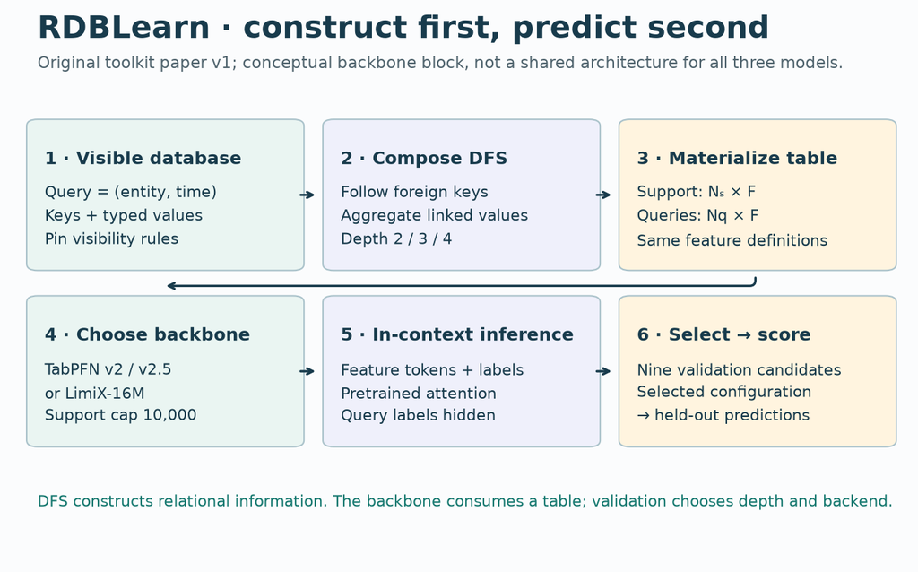

The feature builder is deterministic once the database, transformations and depth are fixed. The **in-context learning (ICL)** predictor reads labeled support rows and unlabeled query rows. Its pretrained parameters supply prior knowledge; fitting support does not imply retraining that foundation model from scratch.

For the original toolkit experiment, depth ∈ {2,3,4} and backend ∈ {TabPFN v2, TabPFN v2.5, LimiX-16M} give nine validation candidates. Each uses at most 10,000 support examples. Validation chooses the configuration; test labels score the selected configuration. [Toolkit §5](https://arxiv.org/html/2602.18495v1#S5)

**Implementation scope.** B14 implements the key temporal and aggregation mechanisms visibly. It also includes the original harness and backend source for inspection. The small ridge/kernel predictors below are course diagnostics, not reimplementations of either foundation model. Original backbone pretraining is outside this lesson's executed scope.

## 2 · A timestamp is an information contract

A **query key** is the pair `(entity_id, prediction_time)`. A driver can occur at several times, so joining or scoring by driver ID alone can silently mix predictions.

A **database snapshot cutoff** limits the newest database state available to an evaluation phase. A record's **event time** says when the event occurred. Its **available time** says when the record became usable. These may differ: yesterday's result can arrive tomorrow.

### Worked example · one query, four candidate records

Query: entity A at day 14. Database snapshot: day 10. Local feature:4.

| Record | Event day | Available day | Value | Visible at boundary 10? |
| --- | --- | --- | --- | --- |
| A1 | 2 | 3 | 2 | Yes |
| A2 | 6 | 7 | 6 | Yes |
| A3 | 7 | 12 | 100 | No: arrived later |
| A4 | 10 | 10 | 20 | No: event at strict boundary |

The effective boundary is `min(14,10)=10`. The course rule requires `event_time < boundary` and `available_time ≤ boundary`. We read values `[2,6]`: count 2, mean 4, last 6. The feature row is `[local4, count 2, mean 4, last 6]`. A late record cannot enter merely because its event date is old.

This two-clock course rule is deliberately explicit. **The historical benchmark supplies event timestamps, not a complete arrival-time ledger.** Matching a release's temporal code does not prove operational availability for every field. The code's exact `<`/`≤` behavior must also be pinned; changing equality conventions is a protocol change.

### Inner and outer snapshots

During **inner validation**, fit on training labels and choose settings using validation labels. Freeze the database at the validation cutoff. During **outer evaluation**, use the test cutoff and the declared final-fit support policy. **Refit** means fitting the selected predictor again on its permitted final support; TabPFN-Rel adds validation examples to that support.

For the selected F1 task, the verified release cutoffs are **2005-01-01 for validation and 2010-01-01 for test**. There are 11,411 training queries, 566 validation queries and 702 test queries. Later test query dates do not unlock later database events. Anchor-derived features such as time-since-event may still change even when the database is frozen. [RelArena temporal protocol](https://github.com/PriorLabs/relarena/blob/e89002200e18be6d8d7a55f8a5ab50c993ce4d5d/docs/temporal-validation.md)

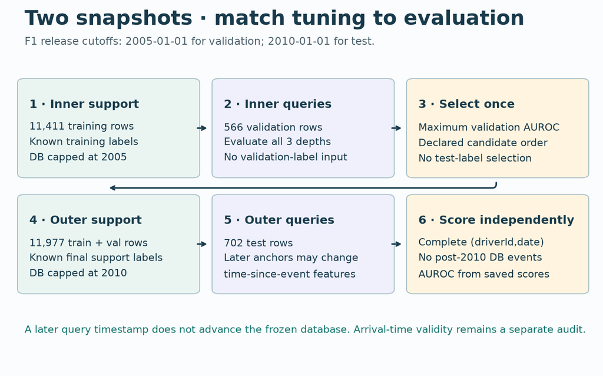

**Target history needs its own clock.** A label for a 30-day prediction window is not necessarily known at the window's start. B14 checks the full F1 support schedule for unfinished earlier windows under `available_at = anchor + 30days`. That schedule check does not reconstruct actual label publication times or prove all database fields safe.

## 3 · TabPFN-Rel changes several things at once

### Model architecture · TabPFN-Rel OSS

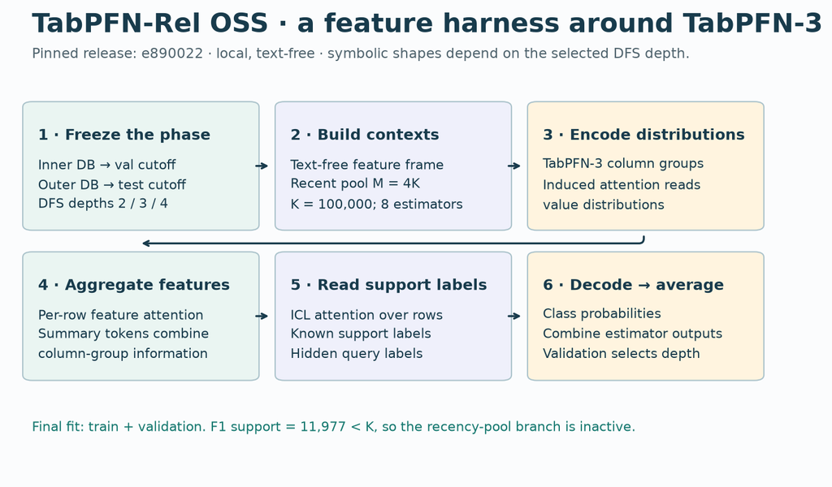

TabPFN-Rel keeps the relational-feature-to-table interface. Its release uses TabPFN-3, a larger support budget, a recency-aware context strategy and train-plus-validation final support. Its benchmark also corrects the inner database snapshot. The hosted variant adds entity text; the local OSS variant is text-free. [RelArena §2.2](https://arxiv.org/html/2608.16319v2#S2.SS2)

The pinned source sets a per-estimator context cap **K=100,000**, a recent pool cap **M=4K**, and an ensemble default of eight estimators. If the support has at most M rows, the hard-pool implementation returns to the backbone's ordinary subsampling path. **On this F1 task, 11,977 final support rows are below K:** the recency-pool branch is inactive. Do not explain a measured F1 gain using a branch the task never takes. [Original context code](https://github.com/PriorLabs/relarena/blob/e89002200e18be6d8d7a55f8a5ab50c993ce4d5d/src/relarena/models/tabpfn_rel/context.py)

**A model comparison is not automatically a backbone ablation.** If the new pipeline changes features, contexts, database cutoffs, refitting and the predictor, its score measures the joint change. To isolate the predictor, materialize one feature matrix, freeze support/query identities and preprocessing, and feed those exact arrays to both backbones.

**Predict before reading:** which records may this query read? Which factors must stay fixed to isolate the predictor?

RelArena's original RDBLearn comparison has six candidates: three depths and two TabPFN backends. It omits LimiX. The toolkit paper had nine. RelArena separates **models**, which use the framework's declared tuning process, from **systems**, which can use a custom tuning procedure. Its release leaderboard uses one seed, not a multi-seed stability study. [RelArena §§2.1/3.1 and Appendix B](https://arxiv.org/html/2608.16319v2#S3.SS1)

## 4 · Hold the table fixed, then change the predictor

**Predict before reading:** which records may this query read? Which factors must stay fixed to isolate the predictor?

**Course experiment, frozen before fitting.** Generate 128 entities and timestamped events for each of seeds 0/1/2. Each entity has a local numeric attribute independent of its history signal. Support contains four query dates per entity (512 rows); test has two dates (256 rows). Features freeze at day 100. Final support includes day 80 labels, whose declared ten-day windows have finished by day 90.

The constructed outcome is `0.4×local + 1.5×sin(history_mean) + 0.15×last_value + noise`, with noise SD 0.1. This deliberately favors a relational summary and allows a nonlinear predictor to help. It tests whether the implementation isolates these effects; it does not estimate their frequency in real databases.

**Vary two factors.** Use entity-only `[local]` or relational `[local,count,mean,last]` features. Within each representation, compare linear ridge regression with RBF kernel ridge regression. Both have fixed regularization α = 1 and support-only standardization. The RBF similarity is `exp(−squared_distance / feature_count)`. Neither predictor tunes on the test set.

**Read the code.** Ridge solves a regularized linear system for coefficients. Kernel ridge solves for weights on similarities to support rows. The latter is nonlinear in the feature values, but neither model is a pretrained ICL transformer. The same live `flatten`, `standardize` and `predict` functions power the notebook's experiment.

| Features | Predictor | Fixed-snapshot MSE, mean ± SD | Rolling-policy MSE, mean ± SD |
| --- | --- | --- | --- |
| entity-only | ridge | 1.69207 ± 0.07121 | 1.69207 ± 0.07121 |
| entity-only | rbf | 1.60746 ± 0.03372 | 1.60746 ± 0.03372 |
| relational | ridge | 0.41460 ± 0.03703 | 0.40847 ± 0.03518 |
| relational | rbf | 0.19634 ± 0.00654 | 0.31005 ± 0.01111 |

Author measurements: 12 fits; 3,072 fixed + 3,072 rolling predictions. Lower MSE is better. Rolling uses later events and is a different information policy; it reuses fitted support.

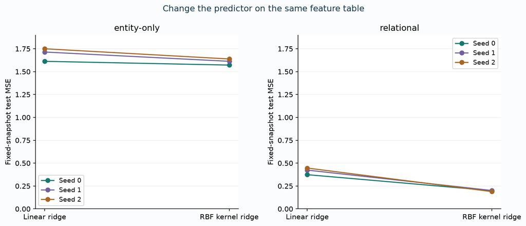

**What the result permits.** Relational features improve both course predictors on every seed. The nonlinear predictor improves further on the identical relational table. This supports the controlled demonstration; it does not establish RDBLearn or TabPFN-Rel superiority, whole-paper parity, or a result on unseen real databases. SD is across three synthetic seeds, not a confidence interval or uncertainty across benchmark databases.

**Falsification checks.** Append a huge post-snapshot event: legal features and predictions must stay fixed. Change held-out labels: features and fitted predictions must stay fixed. Deliberately let later queries read later events: that changes the information policy, so any resulting improvement is not a fair backbone gain. The saved packet includes all fixed and rolling-policy predictions, not just favorable examples.

## 5 · The full reproduction contract

**Named target: B14-TABPFNREL-OSS-F1-DNF.** Reproduce the complete selected task from RelArena v2 Table 4: all three depth candidates, seed0, complete official splits, and default/selected refits. The published target is AUROC 0.7145. **AUROC** is the probability that a randomly selected positive gets a higher score than a negative, with ties contributing one half.

**COMPLETE_SELECTED_RELEASE_CLOSE** · Fresh complete three-depth search and both final refits. Validation selects depth 3. Selected test AUROC: 0.712838530 versus the published 0.7145 (absolute difference 0.001661470). All five evaluations and 3,102 predictions were independently scored. Historical checkpoint byte identity remains NOT_ESTABLISHED; the full suite and pretraining remain NOT_RUN.

| Depth | Fresh validation AUROC | Fresh test AUROC | Role |
| --- | --- | --- | --- |
| 2 | 0.606422 | 0.712848 | unselected / default |
| 3 | 0.624671 | 0.712839 | selected |
| 4 | 0.614177 | NOT_EVALUATED | unselected |

Fresh single-seed released-checkpoint inference. No uncertainty across seeds is estimated. Unselected nondefault settings have no test score by design.

The tagged source records validation scores 0.608200 / 0.619438 / 0.614395 for depths 2/3/4. Validation selects depth 3, whose recorded test AUROC is 0.714468355. These are **released reference results**, not B14 measurements. We do not select depth 3 in advance just because the reference reports it. [Source result table](https://github.com/PriorLabs/relarena/blob/e89002200e18be6d8d7a55f8a5ab50c993ce4d5d/baseline_results/results.csv)

**Budget:** $10 aggregate; stop at $8, reserve $2. Preparation, feature construction, failed attempts, inference and verification count. Local execution has a 3,600-second aggregate limit. Missing dependencies, source failures, mismatched data, unauthenticated checkpoints or an unaffordable complete run stop the reproduction. They never authorize reducing the depth grid or support budget silently.

### RDBLearn's separate source issue

Fresh execution of the original full RDBLearn preprocessor reproduces the known-category inconsistency in the recorded environment. After fitting b/c/d, an unseen a changes known codes from 0/1/2 to 1/2/3; numeric controls remain unchanged. This is a synthetic source diagnostic, not a measured F1 score effect. The original toolkit reproduction retains its separate source gate.

The original toolkit's preprocessing and RelArena's adapted RDBLearn wrapper are distinct implementations. The latter passes categorical columns to the backbone rather than using the original label encoder. An issue in one cannot be transferred to the other by name alone. Conversely, a corrected pipeline is a new declared release comparison, not retrospective proof of historical identity.

Read the full protocol and deviation ledger (see the included contract) for exact versions, commands, outcomes and unrun work. Full 21-task reproduction, hosted text-enabled inference, backbone pretraining and historical identity are separate claims.

## TODO 1 · flatten

Build one row per complete query key. Reject duplicate events/keys and unknown entities. Use the declared event/arrival boundary; return local,count,mean,last. Empty histories return zero aggregates.

```python
def flatten(entities, events, queries, snapshot):
    """One row/query: local value, count, mean, last value. No label input.

    Event time is strictly before min(query time, database snapshot).
    Arrival time may equal that boundary. Duplicate events are rejected rather
    than multiplied by a join. Empty histories have count/mean/last all zero.
    """
    if len({e[0] for e in events}) != len(events):
        raise ValueError('Duplicate physical event')
    if len(set(map(tuple,queries))) != len(queries):
        raise ValueError('Duplicate query identity')
    rows=[]
    for entity, time in queries:
        if entity not in entities: raise ValueError('Unknown entity')
        cutoff=min(time,snapshot)
        visible=[e for e in events if e[1]==entity and e[2]<cutoff and e[3]<=cutoff]
        visible.sort(key=lambda e:(e[2],e[0]))
        values=[e[4] for e in visible]
        rows.append([entities[entity],len(values),sum(values)/len(values) if values else 0.,values[-1] if values else 0.])
    return np.asarray(rows,dtype=np.float64)
```

```python
entities={1:4.};events=[(0,1,2,3,2.),(1,1,6,7,6.),(2,1,7,12,100.),(3,1,10,10,20.)]
np.testing.assert_array_equal(flatten(entities,events,[(1,14)],10),[[4,2,4,6]])
np.testing.assert_array_equal(flatten(entities,events+[(4,1,11,12,999.)],[(1,14)],10),[[4,2,4,6]])
print("CHECK passed: flatten")
```

```
CHECK passed: flatten
```

## TODO 2 · standardize

Return normalized support and query arrays. Fit mean and population SD on support only; use scale1 for a constant column.

```python
def standardize(support, query):
    """Freeze mean/population SD from the support, including constant columns."""
    mean=np.mean(support,axis=0);scale=np.std(support,axis=0)
    scale=np.where(scale==0,1.,scale)
    return (support-mean)/scale,(query-mean)/scale
```

```python
a,b=standardize(np.array([[1.,5],[3.,5]]),np.array([[100.,5.]]))
np.testing.assert_array_equal(a,[[-1,0],[1,0]])
np.testing.assert_array_equal(b,[[98,0]])
print("CHECK passed: standardize")
```

```
CHECK passed: standardize
```

## TODO 3 · predict

Solve fixed-alpha1 linear ridge or RBF kernel ridge. Center support labels around their mean. RBF gamma=1/feature_count; use the same support and query arrays in both arms.

```python
def predict(support, labels, query, backbone):
    """Fixed alpha=1. Mean-centered y; explicit linear or RBF kernel solve.

    The inputs must already be standardized from support only. The mean target
    is the unpenalized offset. RBF gamma=1/feature_count. No hyperparameter tuning.
    """
    support=np.asarray(support);query=np.asarray(query);labels=np.asarray(labels)
    offset=float(labels.mean());y=labels-offset
    if backbone=='ridge':
        coef=np.linalg.solve(support.T@support+np.eye(support.shape[1]),support.T@y)
        return offset+query@coef
    if backbone=='rbf':
        def kernel(a,b):
            dist=np.sum((a[:,None,:]-b[None,:,:])**2,axis=2)
            return np.exp(-dist/support.shape[1])
        weights=np.linalg.solve(kernel(support,support)+np.eye(len(support)),y)
        return offset+kernel(query,support)@weights
    raise ValueError('Unknown backbone')
```

```python
x=np.array([[-1.],[1.]]);y=np.array([-1.,1.]);q=np.array([[0.],[1.]])
np.testing.assert_allclose(predict(x,y,q,'ridge'),[0,2/3])
r=np.exp(-4);np.testing.assert_allclose(predict(x,y,q,'rbf'),[0,(1-r)/(2-r)],atol=1e-12)
print("CHECK passed: predict")
```

```
CHECK passed: predict
```

## PROVIDED · Query-key scoring and the generated database

The generator uses your aggregation function to construct outcomes. The predictor does not receive held-out labels. Query keys contain entity and date; repeated entities are intentional.

```python
def keyed_mse(keys, labels, predictions):
    """Require an exact bijection of full keys before scoring."""
    keys=list(map(tuple,keys));got=[tuple(r['key']) for r in predictions]
    if len(set(keys))!=len(keys) or len(set(got))!=len(got) or set(keys)!=set(got):
        raise ValueError('Prediction keys are not a complete bijection')
    lookup={tuple(r['key']):float(r['prediction']) for r in predictions}
    a=np.array([lookup[k] for k in keys]);y=np.asarray(labels)
    if len(y)!=len(keys) or not np.all(np.isfinite(a)) or not np.all(np.isfinite(y)):
        raise ValueError('Invalid prediction/label values')
    return float(np.mean((a-y)**2))

def make_world(seed):
    """128 entities; an independent local feature and a nonlinear history signal."""
    rng=np.random.default_rng(seed)
    entities={i:float(v) for i,v in enumerate(rng.normal(size=128))}
    latent=rng.uniform(-3,3,128);events=[]
    for day in range(0,120,5):
        for i in entities:
            value=float(latent[i]+.6*np.sin(day/12+i)+rng.normal(scale=.2))
            events.append((len(events),i,day,day+1,value))
    support=[(i,t) for t in [20,40,60,80] for i in entities]
    query=[(i,t) for t in [100,110] for i in entities]
    # Outcomes depend on history up to each query, representing a rolling world.
    # Evaluation features are frozen at day100, so later queries face staleness.
    def labels(keys):
        f=flatten(entities,events,keys,120)
        return .4*f[:,0]+1.5*np.sin(f[:,2])+.15*f[:,3]+rng.normal(scale=.1,size=len(keys))
    return dict(entities=entities,events=events,support=support,query=query,y=labels(support),target=labels(query))
```

## CHECK · Complete paired experiment

Your three live functions are called below. We fit all 12 conditions and retain every prediction under fixed and rolling query information. Rolling predictions reuse the same fitted support.

```python
def run_diagnostic():
    """12 fits, two representations x two predictors x three paired seeds.

    Final support includes validation day80: labels mature by day90. No tuning
    uses those labels. Rolling predictions reuse fitted support and change only
    query features; they are a different information policy, not a new fit.
    """
    conditions=[]
    for seed in range(3):
        w=make_world(seed);s=flatten(w['entities'],w['events'],w['support'],100)
        q=flatten(w['entities'],w['events'],w['query'],100)
        rolling=flatten(w['entities'],w['events'],w['query'],120)
        extra=w['events']+[(999999,0,105,106,1e6)]
        assert np.array_equal(q,flatten(w['entities'],extra,w['query'],100))
        for feature,cols in [('entity-only',[0]),('relational',[0,1,2,3])]:
            a,b=standardize(s[:,cols],q[:,cols]);_,c=standardize(s[:,cols],rolling[:,cols])
            identity=hashlib.sha256(a.tobytes()+b.tobytes()+json.dumps(w['support']).encode()).hexdigest()
            for backbone in ['ridge','rbf']:
                both=predict(a,w['y'],np.vstack([b,c]),backbone);scores=both[:len(b)];roll=both[len(b):]
                rows=[dict(key=list(k),label=float(y),prediction=float(p),rolling_prediction=float(r)) for k,y,p,r in zip(w['query'],w['target'],scores,roll)]
                conditions.append(dict(seed=seed,features=feature,backbone=backbone,input_sha256=identity,support_rows=len(a),query_rows=len(b),mse=keyed_mse(w['query'],w['target'],rows),rolling_mse=float(np.mean((roll-w['target'])**2)),predictions=rows))
    return dict(status='COMPLETE_COURSE_DIAGNOSTIC',fits=12,predictions=3072,rolling_predictions=3072,seed_count=3,scope='Synthetic regression; not a foundation-model or paper reproduction',conditions=conditions)
report=run_diagnostic()
for row in report["conditions"]:print(row["seed"],row["features"],row["backbone"],round(row["mse"],6))
(workspace/"course-results.json").write_text(json.dumps(report,indent=2))
```

```
0 entity-only ridge 1.612455
0 entity-only rbf 1.571403
0 relational ridge 0.37383
0 relational rbf 0.199217
1 entity-only ridge 1.714107
1 entity-only rbf 1.612744
1 relational ridge 0.423803
1 relational rbf 0.200947
2 entity-only ridge 1.749662
2 entity-only rbf 1.638223
2 relational ridge 0.446156
2 relational rbf 0.188863
```

```
683252
```

## CHECK · Independent complete-key scorer

This second scorer uses scalar math and a fresh reconstruction of labels. It refuses missing queries and duplicated identities.

```python
def audit(report):
 assert report['fits']==12 and len(report['conditions'])==12
 seen=set();count=0
 for r in report['conditions']:
  signature=(r['seed'],r['features'],r['backbone']);assert signature not in seen;seen.add(signature)
  w=make_world(r['seed']);keys=w['query'];rows=r['predictions'];assert len(rows)==len(keys)==256
  lookup={tuple(x['key']):x for x in rows};assert len(lookup)==len(rows) and set(lookup)==set(keys)
  errors=[];rolling=[]
  for k,y in zip(keys,w['target']):
   x=lookup[k];assert x['label']==float(y);assert math.isfinite(x['prediction'])
   errors.append((x['prediction']-y)**2);rolling.append((x['rolling_prediction']-y)**2)
  assert abs(math.fsum(errors)/len(errors)-r['mse'])<1e-12
  assert abs(math.fsum(rolling)/len(rolling)-r['rolling_mse'])<1e-12
  count+=len(rows)
 assert seen=={(s,f,b) for s in range(3) for f in ['entity-only','relational'] for b in ['ridge','rbf']}
 for s in range(3):
  for f in ['entity-only','relational']:
   a=[r for r in report['conditions'] if r['seed']==s and r['features']==f]
   assert len({r['input_sha256'] for r in a})==1
 return count
assert audit(report)==3072
print("All 3,072 fixed and 3,072 rolling predictions independently scored")
```

```
All 3,072 fixed and 3,072 rolling predictions independently scored
```

## EXIT · Written defense

Explain the two-clock trace; give a feature-collision example; name the exact factor the swap isolates; explain why a rolling-snapshot score is incomparable to fixed-snapshot results. Interpret the paper status separately from course success. Ask the teacher for feedback; revisit after 1/7/30 days. Learner status remains PENDING_WRITTEN_DEFENSE.

## CHECK · Replay the complete selected-paper evidence

These are saved author predictions from fresh GPU inference, not inference in this notebook. Authenticate the packet, match every official validation/test key and label, independently score all five evaluations, then verify that validation selected the tested winner.

```python
packet=base64.b64decode('UEsDBBQAAAAIAJMARF1E2U7nxRUBAFVwEAASAAAAb2ZmaWNpYWwta2V5cy5q…')
assert hashlib.sha256(packet).hexdigest()=='e3d35dcab3b6167077ebb40fefc2ca0c579d473874b46ad2ac0c88a458fed9ad'
with zipfile.ZipFile(io.BytesIO(packet)) as z:z.extractall(workspace/"paper-evidence")
```

```python
def auroc(y,p):
 pos=[float(v) for a,v in zip(y,p) if a==1];neg=[float(v) for a,v in zip(y,p) if a==0]
 assert pos and neg and len(pos)+len(neg)==len(y)
 return math.fsum((a>b)+.5*(a==b) for a in pos for b in neg)/(len(pos)*len(neg))

def audit_paper(root,expected):
 r=json.loads((root/'result.json').read_text());assert r['status']=='COMPLETE';trials=r['trials'];full=r['phase']=='full'
 assert len(trials)==(3 if full else 1)
 if full:assert [t['config']['max_depth'] for t in trials]==[2,3,4]
 rows=[]
 for t in trials:
  assert not t['error']
  for split in ['val','test']:
   file=root/(t['config_tag']+'-'+split+'.npz')
   if not file.exists():
    assert split=='test' and t['test_score'] is None;continue
   with np.load(file,allow_pickle=False) as a:
    k=list(zip(a['entity'].tolist(),a['date'].tolist()));y=a['label'];p=a['prediction'].reshape(-1)
    assert len(k)==len(set(k))==len(p);assert np.all(np.isfinite(p))
    exp=expected[split];mapping={(x['entity'],x['date']):x['label'] for x in exp}
    assert set(k)==set(mapping)
    assert all(int(label)==mapping[key] for key,label in zip(k,y))
    score=auroc(y,p);assert abs(score-t[split+'_score'])<1e-12
    rows.append(dict(config=t['config_tag'],depth=t['config']['max_depth'],split=split,rows=len(k),auroc=score,sha256=hashlib.sha256(file.read_bytes()).hexdigest()))
 if full:
  selected=max(trials,key=lambda t:t['val_score']);assert selected['config_id']==r['selected']
  default=next(t for t in trials if t['config_tag']=='default')
  assert {x['config'] for x in rows if x['split']=='test'}=={default['config_tag'],selected['config_tag']}
  assert selected['test_score'] is not None
 return dict(status='PASS',phase=r['phase'],evaluations=len(rows),prediction_rows=sum(x['rows'] for x in rows),rows=rows,selected_depth=selected['config']['max_depth'] if full else None,selected_test_auroc=selected['test_score'] if full else None)
expected=json.loads((workspace/"paper-evidence/official-keys.json").read_text())
paper_replay=audit_paper(workspace/"paper-evidence/full",expected)
print(paper_replay)
```

```
{'status': 'PASS', 'phase': 'full', 'evaluations': 5, 'prediction_rows': 3102, 'rows': [{'config': 'default', 'depth': 2, 'split': 'val', 'rows': 566, 'auroc': 0.606421768707483, 'sha256': 'e9f117868a60a2207592ec6d87da35a3d4226318110182bb93a726323bb640f6'}, {'config': 'default', 'depth': 2, 'split':…
```

## NEXT STEP · Exact source and selected-paper operator

This authenticated archive includes the original harness, complete TabPFN-3 architecture, original RDBLearn source and licenses. Extraction does not run a model. The contract describes the separate environments and full target. The following gate is OFF by default.

```python
archive=base64.b64decode('UEsDBBQAAAAIAAAAQ131WmZaZQQAADIJAAAYAAAAbGFicy9fYXVkaXRfcGFw…=')
assert hashlib.sha256(archive).hexdigest()=='82be65a5fdd952ce3c04405550784bd3a9ba67c6ad30b9bc32aa7fbb450ed162'
with zipfile.ZipFile(io.BytesIO(archive)) as z:z.extractall(workspace)
manifest=json.loads((workspace/"source-manifest.json").read_text())
for name,h in manifest.items():assert hashlib.sha256((workspace/name).read_bytes()).hexdigest()==h,name
print("Authenticated",len(manifest),"source files")
```

```
Authenticated 432 source files
```

```python
RUN_PAPER_REPRO=False
if RUN_PAPER_REPRO:
    subprocess.run([sys.executable,str(workspace/"labs/_reproduce_b14.py"),"--show-plan"],check=True)
    print("The displayed plan is not inference. Follow b14-reproduction.md for the isolated runner and admission checks.")
```

## Source appendix · Read the actual released operations

The sections below are complete original files, displayed as source listings rather than executed notebook cells. Course ridge/kernel code above is not substituted for these models. Neural pretraining is not executed here; this lesson targets released-checkpoint inference.

### RDBLearn original estimator

Pinned file: `original-rdblearn/rdblearn/rdblearn/estimator.py`. Read alongside the corresponding architecture step; full dependencies and licenses are in the archive.

```
from typing import Optional, Dict, Union, List
import pandas as pd
import numpy as np
from loguru import logger
from sklearn.base import BaseEstimator, ClassifierMixin, RegressorMixin
import fastdfs
from fastdfs import RDB, DFSConfig
from fastdfs.utils.type_utils import safe_convert_to_string
from fastdfs.transform import (
    RDBTransformWrapper, RDBTransformPipeline, HandleDummyTable,
    FeaturizeDatetime, FillMissingPrimaryKey,
    FilterColumn, CanonicalizeTypes
)

from .config import RDBLearnConfig
from .preprocessing import TabularPreprocessor
from .constants import RDBLEARN_DEFAULT_CONFIG, TARGET_HISTORY_TABLE_NAME

class RDBLearnEstimator(BaseEstimator):
    def __init__(
        self,
        base_estimator,
        config: Optional[Union[RDBLearnConfig, dict]] = None
    ):
        self.base_estimator = base_estimator

        if isinstance(config, RDBLearnConfig):
            self.config = config
        else:
            # Start with defaults
            config_dict = RDBLEARN_DEFAULT_CONFIG.copy()
            # Update with user provided dict if any
            if isinstance(config, dict):
                config_dict.update(config)

            self.config = RDBLearnConfig(**config_dict)

        self.rdb_ = None
        self.preprocessor_ = None
        self.key_mappings_ = None
        self.cutoff_time_column_ = None

        self.history_df_ = None
        self.target_history_fks_ = None
        self.train_cutoff_time_column_ = None

    def _ensure_keys_are_strings(self, X: pd.DataFrame, key_mappings: Dict[str, str]) -> None:
        """Modifies X in place, using safe_convert_to_string for consistency with RDB."""
        for col in key_mappings.keys():
            if col in X.columns:
                X[col] = safe_convert_to_string(X[col])


    def _downsample(
        self,
        data: pd.DataFrame,
        target_column: str,
        task_type: str,
        max_samples: int,
        stratified_sampling: bool = False
    ) -> pd.DataFrame:
        """Downsample data to max_samples."""
        if len(data) <= max_samples:
            return data

        logger.info(f"Downsampling training set from {len(data)} to {max_samples} samples.")

        X = data.drop(columns=[target_column])
        y = data[target_column].values

        if task_type == "regression":
            idx = np.random.choice(len(X), max_samples, replace=False)
            return data.iloc[idx].reset_index(drop=True)

        # Classification
        if not stratified_sampling:
            unique_labels = np.unique(y)
            selected_indices = []
            for label in unique_labels:
                class_indices = np.where(y == label)[0]
                if len(class_indices) > 0:
                    selected_idx = np.random.choice(class_indices, 1)[0]
                    selected_indices.append(selected_idx)

            remaining_samples = max_samples - len(selected_indices)
            if remaining_samples > 0:
                mask = np.ones(len(X), dtype=bool)
                mask[selected_indices] = False
                eligible_indices = np.where(mask)[0]

                if len(eligible_indices) > 0:
                    additional_indices = np.random.choice(
                        eligible_indices,
                        min(remaining_samples, len(eligible_indices)),
                        replace=False
                    )
                    selected_indices.extend(additional_indices)

            np.random.shuffle(selected_indices)
            idx = np.array(selected_indices)
            return data.iloc[idx].reset_index(drop=True)

        else:
            unique_labels, label_counts = np.unique(y, return_counts=True)
            n_classes = len(unique_labels)
            samples_per_class = max(1, max_samples // n_classes)

            balanced_indices = []
            remaining_indices = []

            for label in unique_labels:
                class_indices = np.where(y == label)[0]
                if len(class_indices) == 0:
                    continue

                if len(class_indices) <= samples_per_class:
                    balanced_indices.extend(class_indices)
                else:
                    sampled_indices = np.random.choice(class_indices, samples_per_class, replace=False)
                    balanced_indices.extend(sampled_indices)
                    mask = np.ones(len(class_indices), dtype=bool)
                    mask[np.isin(class_indices, sampled_indices)] = False
                    remaining_indices.extend(class_indices[mask])

            samples_needed = max_samples - len(balanced_indices)
            if samples_needed > 0 and len(remaining_indices) > 0:
                additional_samples = np.random.choice(
                    remaining_indices,
                    min(samples_needed, len(remaining_indices)),
                    replace=False
                )
                balanced_indices.extend(additional_samples)

            np.random.shuffle(balanced_indices)
            balanced_indices = balanced_indices[:max_samples]
            idx = np.array(balanced_indices)
            return data.iloc[idx].reset_index(drop=True)

    def _prepare_rdb(self, rdb: RDB) -> RDB:
        # Augment with target history if enabled and available
        if (
            self.config.enable_target_augmentation
            and self.history_df_ is not None
            and self.target_history_fks_ is not None
            and self.train_cutoff_time_column_ is not None
        ):
            logger.info(f"Augmenting RDB with {TARGET_HISTORY_TABLE_NAME} table.")

            rdb = rdb.add_table(
                dataframe=self.history_df_,
                name=TARGET_HISTORY_TABLE_NAME,
                time_column=self.train_cutoff_time_column_,
                foreign_keys=self.target_history_fks_
            )
            rdb = rdb.canonicalize_key_types()
            rdb.validate_key_consistency()

        logger.info("Preparing RDB with transformation pipeline.")
        pipeline = RDBTransformPipeline([
            HandleDummyTable(),
            FillMissingPrimaryKey(),
            RDBTransformWrapper(FeaturizeDatetime(features=["epochtime"])),
            RDBTransformWrapper(FilterColumn(drop_dtypes=["text"])),
            RDBTransformWrapper(CanonicalizeTypes()),
        ])
        return pipeline(rdb)
```

```
    def fit(
        self,
        X: pd.DataFrame,
        y: pd.Series,
        rdb: RDB,
        key_mappings: Dict[str, str],
        cutoff_time_column: Optional[str] = None,
        **kwargs
    ):
        # 0. Copy and ensure keys are string
        X = X.copy()
        self._ensure_keys_are_strings(X, key_mappings)
        self.key_mappings_ = key_mappings
        self.cutoff_time_column_ = cutoff_time_column

        # 1. Setup Target History Augmentation (Using FULL X, y)
        if self.config.enable_target_augmentation:
            if cutoff_time_column is None:
                logger.debug("enable_target_augmentation is True but cutoff_time_column is None. Skipping augmentation to prevent leakage.")
            else:
                logger.info("Storing target history for augmentation.")

                # Create history dataframe (using current X which is the full train set)
                self.history_df_ = X.copy()
                target_col = y.name or "_RDBL_target"
                self.history_df_[target_col] = y.copy()

                self.train_cutoff_time_column_ = cutoff_time_column

                # Construct foreign keys for the history table
                self.target_history_fks_ = []
                for x_col, rdb_ref in key_mappings.items():
                    if "." in rdb_ref:
                        rdb_table, rdb_col = rdb_ref.split(".", 1)
                        # (this_table, this_col, other_table, other_col)
                        self.target_history_fks_.append((x_col, rdb_table, rdb_col))

        # 2. RDB Transformation (Augments RDB using stored history)
        self.rdb_ = self._prepare_rdb(rdb)

        # 3. Downsampling (Modifies X and y for training)
        if len(X) > self.config.max_train_samples:
            data = X
            target_col = y.name or "_RDBL_target"
            data[target_col] = y

            task_type = "regression" if isinstance(self, RegressorMixin) else "classification"

            downsampled_data = self._downsample(
                data, target_col, task_type,
                self.config.max_train_samples,
                self.config.stratified_sampling
            )
            X = downsampled_data.drop(columns=[target_col])
            y = downsampled_data[target_col]

        # 4. Feature Augmentation
        logger.info("Computing DFS features...")
        dfs_config = self.config.dfs or DFSConfig()

        X_dfs = fastdfs.compute_dfs_features(
            self.rdb_,
            X,
            key_mappings=key_mappings,
            cutoff_time_column=cutoff_time_column,
            config=dfs_config
        )
        logger.debug(f"DFS features: {X_dfs.columns.tolist()}")

        # 5. Preprocessing
        logger.info("Preprocessing augmented features ...")
        self.preprocessor_ = TabularPreprocessor(
            ag_config=self.config.ag_config,
            temporal_diff_config=self.config.temporal_diff,
            cutoff_time=cutoff_time_column
        )
        X_transformed = self.preprocessor_.fit(X_dfs).transform(X_dfs)

        # 6. Model Training
        logger.info("Fitting base estimator ...")
        self.base_estimator.fit(X_transformed, y, **kwargs)

        return self

    def _predict_common(self, X: pd.DataFrame, rdb: Optional[RDB], method: str, **kwargs):
        # 0. Copy and ensure keys are string
        X = X.copy()
        if self.key_mappings_:
            self._ensure_keys_are_strings(X, self.key_mappings_)

        # 2. RDB Selection
        if rdb is None:
            selected_rdb = self.rdb_
        else:
            # Augment new RDB with stored training history!
            selected_rdb = self._prepare_rdb(rdb)

        # 3. Feature Augmentation
        logger.info("Computing DFS features...")

        dfs_config = self.config.dfs or DFSConfig()

        X_dfs = fastdfs.compute_dfs_features(
            selected_rdb,
            X,
            key_mappings=self.key_mappings_,
            cutoff_time_column=self.cutoff_time_column_,
            config=dfs_config
        )


        # 4. Preprocessing
        logger.info("Preprocessing augmented features ...")
        X_transformed = self.preprocessor_.transform(X_dfs)

        # 5. Prediction
        logger.info("Making predictions ...")
        predict_func = getattr(self.base_estimator, method)

        if self.config.predict_batch_size and len(X_transformed) > self.config.predict_batch_size:
            results = []
            for i in range(0, len(X_transformed), self.config.predict_batch_size):
                batch = X_transformed.iloc[i:i+self.config.predict_batch_size]
                results.append(predict_func(batch, **kwargs))

            if isinstance(results[0], dict):
                # Aggregate dictionary results
                aggregated = {}
                for key in results[0].keys():
                    key_results = [r[key] for r in results]
                    if isinstance(key_results[0], np.ndarray):
                        aggregated[key] = np.concatenate(key_results)
                    elif isinstance(key_results[0], (pd.Series, pd.DataFrame)):
                        aggregated[key] = pd.concat(key_results, axis=0)
                    else:
                        print(f"Warning: Unexpected type of key_results: {type(key_results[0])} when aggregating results for key {key}, skipping this key")
                return aggregated
            elif isinstance(results[0], np.ndarray):
                return np.concatenate(results)
            elif isinstance(results[0], (pd.Series, pd.DataFrame)):
                return pd.concat(results, axis=0)
            else:
                return np.concatenate(results)
        else:
            return predict_func(X_transformed, **kwargs)

class RDBLearnClassifier(RDBLearnEstimator, ClassifierMixin):
    def predict(self, X: pd.DataFrame, rdb: Optional[RDB] = None, **kwargs):
        return self._predict_common(X, rdb, method="predict", **kwargs)

    def predict_proba(self, X: pd.DataFrame, rdb: Optional[RDB] = None, **kwargs):
        return self._predict_common(X, rdb, method="predict_proba", **kwargs)
```

```
class RDBLearnRegressor(RDBLearnEstimator, RegressorMixin):
    def predict(self, X: pd.DataFrame, rdb: Optional[RDB] = None, **kwargs):
        return self._predict_common(X, rdb, method="predict", **kwargs)
```

### RDBLearn original preprocessing

Pinned file: `original-rdblearn/rdblearn/rdblearn/preprocessing.py`. Read alongside the corresponding architecture step; full dependencies and licenses are in the archive.

```
from typing import Optional, Dict, Any, List
import pandas as pd
import numpy as np
from sklearn.base import BaseEstimator, TransformerMixin
from sklearn.preprocessing import LabelEncoder
from sklearn.pipeline import Pipeline
from autogluon.features.generators import AutoMLPipelineFeatureGenerator
from loguru import logger
from .config import TemporalDiffConfig


class TypeCastTransformer(BaseEstimator, TransformerMixin):
    """
    Transformer to cast boolean and nullable Int64 columns to float32.
    Handles <NA> values by converting them to np.nan.
    """
    def fit(self, X: pd.DataFrame, y=None):
        self.is_fitted_ = True
        return self

    def transform(self, X: pd.DataFrame):
        X = X.copy()
        for col in X.columns:
            # Check for boolean types
            is_bool = pd.api.types.is_bool_dtype(X[col])
            # Check for nullable Int64 (often comes from mixed sources)
            is_nullable_int = str(X[col].dtype) == 'Int64'

            if is_bool or is_nullable_int:
                # astype('float32') handles mapping <NA>/None/False->0/True->1 correctly
                # and converts <NA> to IEEE 754 NaN
                X[col] = X[col].astype('float32')
        return X


class TemporalDiffTransformer(BaseEstimator, TransformerMixin):
    def __init__(self, config: TemporalDiffConfig, cutoff_time_col: Optional[str] = None):
        self.config = config
        self.cutoff_time_col = cutoff_time_col
        self.timestamp_columns_: List[str] = []

    def _sanitize_column_name(self, col: str) -> str:
        sanitized = col.replace('(', '_').replace(')', '').replace('.', '_')
        while '__' in sanitized:
            sanitized = sanitized.replace('__', '_')
        sanitized = sanitized.strip('_')
        return sanitized

    def fit(self, X: pd.DataFrame, y=None):
        # Find all epochtime columns
        all_epochtime_cols = [
            col for col in X.columns
            if '_epochtime' in col and col not in self.config.exclude_columns
        ]

        # Drop epochtime columns containing 'std' — std of timestamps is meaningless.
        self.columns_to_drop_ = [
            col for col in all_epochtime_cols if 'std' in col.lower()
        ]

        # Transform all remaining epochtime columns
        self.timestamp_columns_ = [
            col for col in all_epochtime_cols if col not in self.columns_to_drop_
        ]

        if self.timestamp_columns_:
            logger.info(f"TemporalDiffTransformer: Found {len(self.timestamp_columns_)} timestamp columns for transformation.")
        if self.columns_to_drop_:
            logger.info(f"TemporalDiffTransformer: Will drop {len(self.columns_to_drop_)} epochtime columns containing 'std'.")

        return self

    def transform(self, X: pd.DataFrame):
        X = X.copy()

        # Drop unwanted epochtime columns first
        if self.columns_to_drop_:
            cols_present = [col for col in self.columns_to_drop_ if col in X.columns]
            if cols_present:
                X = X.drop(columns=cols_present)

        if not self.timestamp_columns_:
            return X

        if self.cutoff_time_col is None or self.cutoff_time_col not in X.columns:
            return X

        cutoff_series = X[self.cutoff_time_col]
        cutoff_nano = (cutoff_series.astype('datetime64[ns]') - np.array(0).astype('datetime64[ns]')).astype('int64')

        for col in self.timestamp_columns_:
            if col not in X.columns:
                continue

            timestamp_nano = X[col].values
            time_diff = (cutoff_nano - timestamp_nano).astype('float64')

            sanitized_name = self._sanitize_column_name(col)
            feature_name = f"{sanitized_name}_diff"

            X[feature_name] = time_diff
            X = X.drop(columns=[col])

        logger.info(f"TemporalDiffTransformer: Generated {len(self.timestamp_columns_)} temporal difference features.")
        return X


class SafeLabelEncoderTransformer(BaseEstimator, TransformerMixin):
    """
    Wraps standard LabelEncoder logic but handles unseen labels dynamically by expanding classes,
    matching original implementation behavior.
    """
    def __init__(self):
        self.label_encoders_ = {}
        self.cat_columns_ = []

    def fit(self, X: pd.DataFrame, y=None):
        # Identify object/category columns
        self.cat_columns_ = X.select_dtypes(include=['object', 'category']).columns.tolist()
        for col in self.cat_columns_:
            le = LabelEncoder()
            # Convert to string to handle mixed types/NaNs consistently
            le.fit(X[col].astype(str))
            self.label_encoders_[col] = le
        return self

    def transform(self, X: pd.DataFrame):
        X = X.copy()
        for col in self.cat_columns_:
            if col in X.columns:
                le = self.label_encoders_[col]
                vals = X[col].astype(str)

                # Check for unseen labels and expand if necessary
                unseen_mask = ~vals.isin(le.classes_)
                if unseen_mask.any():
                    # Extend classes with new unseen labels
                    new_classes = vals[unseen_mask].unique()
                    le.classes_ = np.concatenate([le.classes_, new_classes])
                    # Re-sort if strictly necessary for LabelEncoder, but usually unnecessary for just transform mapping
                    le.classes_ = np.sort(le.classes_)

                X[col] = le.transform(vals)
        return X


class AutoGluonTransformer(BaseEstimator, TransformerMixin):
    """
    Scikit-learn wrapper for AutoGluon's AutoMLPipelineFeatureGenerator.
    """
    def __init__(self, ag_config: Optional[Dict[str, Any]] = None):
        self.ag_config = ag_config
        self.feature_generator_ = None

        self._default_ag_config = {
            "enable_datetime_features": True,
            "enable_raw_text_features": False,
            "enable_text_special_features": False,
            "enable_text_ngram_features": False,
        }
        if self.ag_config:
            self._default_ag_config.update(self.ag_config)

    def fit(self, X: pd.DataFrame, y=None):
        self.feature_generator_ = AutoMLPipelineFeatureGenerator(**self._default_ag_config)
        # AutoGluon generator fits and needs the data
        self.feature_generator_.fit(X=X)
        return self

    def transform(self, X: pd.DataFrame):
        if self.feature_generator_ is None:
            raise RuntimeError("AutoGluonTransformer not fitted.")
        return self.feature_generator_.transform(X)


class TabularPreprocessor(BaseEstimator, TransformerMixin):
    def __init__(
        self,
        ag_config: Optional[Dict[str, Any]] = None,
        temporal_diff_config: Optional[TemporalDiffConfig] = None,
        cutoff_time: Optional[str] = None
    ):
        self.ag_config = ag_config
        self.temporal_diff_config = temporal_diff_config
        self.cutoff_time = cutoff_time
        self.pipeline = None
        self.is_fitted_ = False

    def fit(self, X: pd.DataFrame, y=None):
        """Fit the preprocessor pipeline on training data."""
        steps = []

        # 1. Type Casting (Must be first to fix legacy types)
        steps.append(('type_cast', TypeCastTransformer()))

        # 2. Temporal Features
        if self.temporal_diff_config and self.temporal_diff_config.enabled:
            # We pass the column name for cutoff time so the transformer can find it in X
            steps.append(('temporal', TemporalDiffTransformer(
                config=self.temporal_diff_config,
                cutoff_time_col=self.cutoff_time
            )))

        # 3. Categorical Encoding
        steps.append(('label_encoder', SafeLabelEncoderTransformer()))

        # 4. AutoGluon Features
        steps.append(('autogluon', AutoGluonTransformer(ag_config=self.ag_config)))

        self.pipeline = Pipeline(steps)
        logger.debug(f"Preprocessor pipeline: {self.pipeline}")

        self.pipeline.fit(X, y)
        self.is_fitted_ = True
        return self

    def transform(self, X: pd.DataFrame) -> pd.DataFrame:
        """Transform features using the fitted pipeline."""
        if self.pipeline is None:
            raise RuntimeError("Preprocessor not fitted.")

        return self.pipeline.transform(X)
```

### TabPFN-Rel feature harness

Pinned file: `relarena/src/relarena/models/tabpfn_rel/model.py`. Read alongside the corresponding architecture step; full dependencies and licenses are in the archive.

```
"""`tabpfn-rel` — DFS + a TabPFN foundation model, with opt-in feature/context extras.

Like the open `rdblearn` model, it solves a RelBench entity task by deep feature
synthesis (DFS) — aggregating the linked tables into one flat row per (entity, cutoff)
— and feeding that table to a TabPFN foundation model that predicts the test rows by
in-context learning over the train rows. On top of that it adds four opt-in knobs,
each recovering signal flat-DFS-into-one-TFM-call leaves behind (see
`relarena.models.tabpfn_rel.features` and
`relarena.models.tabpfn_rel.context`):

  1. **Calendar features** — cyclic sin/cos of the cutoff timestamp.
  2. **History lags** — per-entity lags of the target's own past values.
  3. **Text features** — anchor-table free text passed through raw, for a TFM whose
     estimator consumes text columns itself (the hosted-API backend).
  4. **Recency-aware contexts** — `soft_pool` / `hard_pool` build the TFM's
     in-context examples from a recency-weighted pool instead of a uniform sample.

`fit` is the whole story top to bottom: build DFS features for the full train labels
(cached on a warm run; see `relarena.featurization.cache`), apply the
enabled feature extras, then fit the TFM — a seeded downsample for the default
`random` context, or the recency pool for `soft_pool` / `hard_pool`. The expensive
DFS matrix is content-cached, so the downsample / pool selection happens cheaply
afterward (rather than being fused into a pre-DFS slice); text is handled inside
the estimator at fit time.

Two variants are registered, sharing the config validated in the reference sweeps —
TabPFN v3 with hard-pool recency contexts (`K=100k`, `M=4·K`), tuned over DFS depth
only: `tabpfn-rel-local` runs the local TabPFN v3, and `tabpfn-rel-client` runs
through the hosted TabPFN API with anchor-table text passed through raw.
"""

from __future__ import annotations

from typing import Any

import numpy as np
from relbench.base import Database, EntityTask, Table

from relarena.featurization import DFS_MAX_DEPTH, build_dfs_features
from relarena.model import RelArenaModel
from relarena.models._shared.tfm.tfm import TFM_REGISTRY, predict_tfm
from relarena.models.tabpfn_rel.context import ContextStrategy
from relarena.models.tabpfn_rel.features import FeaturePipeline
from relarena.registry import register_model
from relarena.search_space import SearchSpace

#: Depth grid lower bound. Shallower depths yield no DFS features for entity tasks.
_MIN_DEPTH = 2

#: The config validated in the reference sweeps: TabPFN v3 with hard-pool recency
#: contexts (K=100k per estimator, pool M=4·K). Only the DFS depth is tuned.
_DEFAULT_KNOBS: dict[str, Any] = {
    "tfm": "tabpfn-v3",
    "context_strategy": "hard_pool",
    "subsample_samples": 100_000,
    "pool_inflation": 4.0,
    "with_text": False,
}

#: Depth ascending so the default (depth 2) comes first and survives budget truncation.
TABPFN_REL_LOCAL_SPACE = SearchSpace(
    default_overrides={**_DEFAULT_KNOBS, "max_depth": _MIN_DEPTH},
    fixed_grid=[
        {**_DEFAULT_KNOBS, "max_depth": d} for d in range(_MIN_DEPTH, DFS_MAX_DEPTH + 1)
    ],
)

#: Hosted-API variant; the API handles anchor-table text server-side, so text is on.
#: API fits consume service quota, so callers should use `n_trials=0` unless they
#: explicitly want to spend quota on tuning.
_CLIENT_DEFAULT_KNOBS = {
    **_DEFAULT_KNOBS,
    "tfm": "tabpfn-v3-api",
    "with_text": True,
}
TABPFN_REL_CLIENT_SPACE = SearchSpace(
    default_overrides={**_CLIENT_DEFAULT_KNOBS, "max_depth": _MIN_DEPTH},
    fixed_grid=[
        {**_CLIENT_DEFAULT_KNOBS, "max_depth": d}
        for d in range(_MIN_DEPTH, DFS_MAX_DEPTH + 1)
    ],
)


class TabPFNRelModel(RelArenaModel):
    """Shared `tabpfn-rel` implementation; the registered variants pin the backend."""

    #: Depth at which the cached DFS matrix is computed (shallower configs slice it).
    MAX_DEPTH = DFS_MAX_DEPTH

    def fit(
        self,
        task: EntityTask,
        db: Database,
        train_table: Table,
        val_table: Table | None,
        *,
        seed: int,
        time_limit: float | None = None,
    ) -> None:
        """Build DFS features, apply the enabled extras, then fit the TFM.

        The explicitly constructed `CacheConfig` determines whether DFS reads,
        fills, or computes privately; this model does not override that policy.
        """
        self._tfm = self.config.get("tfm", "tabpfn-v3")
        self._depth = int(self.config.get("max_depth", _MIN_DEPTH))
        self._check_text_support()
        self._features = FeaturePipeline(self.config)
        context = ContextStrategy.from_config(self.config)
        # The history pool and the recency contexts use the full train table; only the
        # TFM's context is capped, downstream by the context strategy.
        self._history_table = train_table if task.time_col else None

        df = self._dfs(task, db, train_table)
        if df.shape[1] == 0:
            raise ValueError(f"DFS produced no features at depth {self._depth}.")
        df = self._features.fit_transform(df, task, train_table, db)
        cutoff = train_table.df[task.time_col].to_numpy() if task.time_col else None
        self._fitted = context.fit(
            df,
            train_table.df[task.target_col],
            task.task_type,
            tfm=self._tfm,
            seed=seed,
            context_time=cutoff,
        )

    def predict(self, task: EntityTask, db: Database, table: Table) -> np.ndarray:
        """Build + extend DFS features for `table` and return TFM predictions."""
        df = self._dfs(task, db, table)
        df = self._features.transform(df, task, table, db)
        return predict_tfm(self._fitted, df)

    def warm_cache(
        self, task: EntityTask, db: Database, train_table: Table, eval_table: Table
    ) -> None:
        """Populate the feature cache for this config's fit + predict, without the TFM.

        Runs exactly the `build_dfs_features` + feature-pipeline calls `fit` and
        `predict` make (same cache keys), so a later eval reads them instead of
        recomputing. Construct the model with an explicit fill config; needs only CPU.
        The shared public command is `relarena.featurization.warm_cache`.
        """
        self._tfm = self.config.get("tfm", "tabpfn-v3")
        self._depth = int(self.config.get("max_depth", _MIN_DEPTH))
        self._check_text_support()
        self._features = FeaturePipeline(self.config)
        self._history_table = train_table if task.time_col else None
        train_feats = self._dfs(task, db, train_table)
        self._features.fit_transform(train_feats, task, train_table, db)
        eval_feats = self._dfs(task, db, eval_table)
        self._features.transform(eval_feats, task, eval_table, db)

    def _check_text_support(self) -> None:
        """Raise if `with_text` is set on a TFM that does not support text."""
        if self.config.get("with_text") and not TFM_REGISTRY[self._tfm].supports_text:
            raise ValueError(
                f"with_text is set but TFM {self._tfm!r} does not support text "
                f"features; pick a text-capable TFM or unset with_text."
            )

    def _dfs(self, task: EntityTask, db: Database, table: Table) -> Any:
        features, _ = build_dfs_features(
            task,
            db,
            table,
            depth=self._depth,
            max_depth=self.MAX_DEPTH,
            history_table=self._history_table,
            keep_anchor_columns=True,
            cache=self.cache,
            run_identity=self.run_identity,
        )
        return features


@register_model(search_space=TABPFN_REL_LOCAL_SPACE)
class TabPFNRelLocalModel(TabPFNRelModel):
    """`tabpfn-rel` on the local TabPFN v3, without text features."""

    name = "tabpfn-rel-local"


@register_model(search_space=TABPFN_REL_CLIENT_SPACE)
class TabPFNRelClientModel(TabPFNRelModel):
    """`tabpfn-rel` through the hosted TabPFN API, with raw anchor-table text."""

    name = "tabpfn-rel-client"
```

### Context selection

Pinned file: `relarena/src/relarena/models/tabpfn_rel/context.py`. Read alongside the corresponding architecture step; full dependencies and licenses are in the archive.

```
"""Context-selection strategies for the `tabpfn-rel` TFM fit.

The TFM learns in-context from the train rows; *which* rows it sees per ensemble
estimator is the **context strategy**. `tabpfn-rel` supports exactly one of:

  * `random`    — a uniform seeded downsample to the TFM's context cap (the base
    `rdblearn` behavior; no extra parameters);
  * `hard_pool` — each estimator draws `K` rows from the `M` most-recent rows;
  * `soft_pool` — each estimator draws `K` rows from an `M`-row pool sampled
    with recency-decaying weights (half-weight at the `tau_half_frac` percentile).

`ContextStrategy.from_config` turns the single `context_strategy` config
value (plus that mode's own knobs) into one strategy object — there is no way to
combine modes, and a missing required knob (e.g. the pool `K`) raises here.
`ContextStrategy.fit` then builds and fits the TFM; the pool strategies fit on
the **union** of the per-estimator contexts (bounding the frame the TFM stores) and
pass each estimator's rows as `inference_config={"SUBSAMPLE_SAMPLES": [...]}`.
Categoricals are auto-inferred by the TFM throughout.
"""

from __future__ import annotations

from abc import ABC, abstractmethod
from dataclasses import dataclass
from typing import Any, Callable

import numpy as np
import pandas as pd
from relbench.base import TaskType

from relarena.models._shared.tfm.tfm import FittedTFM, fit_tfm

#: Default ensemble size for the pool strategies when the config pins none.
DEFAULT_POOL_N_ESTIMATORS = 8


def _to_int64_ns(t: np.ndarray) -> np.ndarray:
    """Coerce a per-row cutoff-timestamp array to int64 nanoseconds (sortable)."""
    t = np.asarray(t)
    if np.issubdtype(t.dtype, np.datetime64):
        return t.astype("datetime64[ns]").view("int64")
    if t.dtype == object:
        return pd.to_datetime(t).astype("int64").to_numpy()
    return t.astype("int64")


def soft_pool_subsample_indices(
    t: np.ndarray,
    *,
    K: int,
    M: int,
    n_estimators: int,
    tau_half_frac: float,
    seed: int,
) -> list[np.ndarray] | None:
    """Recency-weighted per-estimator context subsample (`soft_pool`).

    Stage 1 (shared across estimators): draw an `M`-row pool from the `N` context
    rows via Efraimidis-Spirakis weighted sampling, with weight
    `exp(-ln(2)/tau_half_frac · rank_frac)` where `rank_frac` is in `[0, 1]`
    (0 = most recent by `t`). `tau_half_frac=0.1` halves the weight at the 10th
    recency percentile. Stage 2 (per estimator): draw `K` rows uniformly without
    replacement from the pool (pairwise overlap ≈ `K²/M`).

    Returns `None` when `N <= M` (the pool would be everything, so recency
    weighting is inert) — the caller then falls back to TabPFN's uniform path.
    """
    n = len(t)
    if n <= M:
        return None
    rng = np.random.default_rng(seed)
    ti = _to_int64_ns(t)
    order = np.argsort(-ti, kind="stable")  # order[0] = most-recent row index
    ranks = np.empty(n, dtype=np.int64)
    ranks[order] = np.arange(n)  # ranks[row] = recency rank (0 = most recent)
    r_frac = ranks / max(n - 1, 1)
    lam = np.log(2.0) / max(tau_half_frac, 1e-12)
    weights = np.exp(-lam * r_frac)  # strictly positive for every row
    log_u = np.log(rng.random(n))  # strictly negative
    keys = log_u / weights  # Efraimidis-Spirakis key; larger = more likely
    pool = np.argpartition(keys, -M)[-M:]
    return [rng.choice(pool, size=K, replace=False) for _ in range(n_estimators)]


def hard_pool_subsample_indices(
    t: np.ndarray, *, K: int, M: int, n_estimators: int, seed: int
) -> list[np.ndarray] | None:
    """Most-recent-`M` per-estimator context subsample (`hard_pool`).

    Stage 1: the pool is the `M` most-recent rows by `t` (deterministic; ties
    broken by a stable sort). Stage 2: each estimator draws `K` rows uniformly
    without replacement from the pool. Returns `None` when `N <= M` (caller falls
    back to TabPFN's uniform path).
    """
    n = len(t)
    if n <= M:
        return None
    ti = _to_int64_ns(t)
    order = np.argsort(-ti, kind="stable")  # order[0] = most recent
    pool = order[:M]
    rng = np.random.default_rng(seed)
    return [rng.choice(pool, size=K, replace=False) for _ in range(n_estimators)]


class ContextStrategy(ABC):
    """How `tabpfn-rel` picks the TFM's in-context training rows (see module doc)."""

    @abstractmethod
    def fit(
        self,
        df: pd.DataFrame,
        y: pd.Series,
        task_type: TaskType,
        *,
        tfm: str,
        seed: int,
        context_time: np.ndarray | None,
    ) -> FittedTFM:
        """Fit `tfm` on the featurized frame under this strategy.

        `context_time` is the per-row cutoff timestamp (row-aligned with `df` /
        `y`), i.e. each candidate context row's prediction time — what the pool
        strategies rank rows by to over-weight recent ones. `None` (or unused) for
        `random`, which is recency-agnostic; the pools require it.
        """

    @staticmethod
    def from_config(config: dict[str, Any]) -> "ContextStrategy":
        """Build the single strategy the config selects (default `random`).

        Raises on an unknown name, and (for the pools) on a missing
        `subsample_samples` — so a run commits to exactly one valid mode up front.
        """
        builders: dict[str, Callable[[dict[str, Any]], ContextStrategy]] = {
            "random": RandomContext.from_config,
            "hard_pool": HardPoolContext.from_config,
            "soft_pool": SoftPoolContext.from_config,
        }
        name = config.get("context_strategy", "random")
        if name not in builders:
            raise ValueError(
                f"unknown context_strategy {name!r}; choose one of {sorted(builders)}"
            )
        return builders[name](config)


@dataclass(frozen=True)
class RandomContext(ContextStrategy):
    """Uniform seeded downsample to the TFM's context cap (the `rdblearn` default)."""

    def fit(
        self,
        df: pd.DataFrame,
        y: pd.Series,
        task_type: TaskType,
        *,
        tfm: str,
        seed: int,
        context_time: np.ndarray | None = None,
    ) -> FittedTFM:
        """Defer to the base `fit_tfm` (it caps rows itself); recency unused."""
        return fit_tfm(df, y, task_type, tfm=tfm, seed=seed)

    @classmethod
    def from_config(cls, config: dict[str, Any]) -> "RandomContext":
        """Random context takes no parameters."""
        return cls()


@dataclass(frozen=True)
class _PoolContext(ContextStrategy):
    """Shared recency-pool fit; subclasses only differ in how the pool is drawn.

    With `K = subsample_samples` and `M = round(K·pool_inflation)`: optionally cap
    the frame to `subsample_rows` random rows, draw per-estimator contexts from the
    recency pool, then fit on their **union** (bounding the frame the TFM stores) with
    each estimator's rows remapped in and passed as `SUBSAMPLE_SAMPLES`. A degenerate
    pool (`N <= M`) has no union — the TFM fits the whole frame and subsamples `K`.
    """

    subsample_samples: int
    n_estimators: int
    pool_inflation: float
    subsample_rows: int | None

    def fit(
        self,
        df: pd.DataFrame,
        y: pd.Series,
        task_type: TaskType,
        *,
        tfm: str,
        seed: int,
        context_time: np.ndarray | None,
    ) -> FittedTFM:
        """Cap, draw the pool, fit the union (see class doc)."""
        df = df.reset_index(drop=True)
        y = y.reset_index(drop=True)
        t = np.asarray(context_time)

        if self.subsample_rows is not None and len(df) > self.subsample_rows:
            keep = np.random.default_rng(seed).permutation(len(df))[
                : self.subsample_rows
            ]
            df = df.iloc[keep].reset_index(drop=True)
            y = y.iloc[keep].reset_index(drop=True)
            t = t[keep]

        m = int(round(self.subsample_samples * self.pool_inflation))
        idx = self._draw_pool(t, m=m, seed=seed)
        if idx is None:
            subsample_value: Any = self.subsample_samples
        else:
            union = np.unique(np.concatenate(idx))
            df = df.iloc[union].reset_index(drop=True)
            y = y.iloc[union].reset_index(drop=True)
            subsample_value = [np.searchsorted(union, e) for e in idx]

        overrides = {
            "n_estimators": self.n_estimators,
            "inference_config": {"SUBSAMPLE_SAMPLES": subsample_value},
        }
        return fit_tfm(
            df,
            y,
            task_type,
            tfm=tfm,
            seed=seed,
            max_train_samples=len(df),
            overrides=overrides,
        )

    @abstractmethod
    def _draw_pool(
        self, t: np.ndarray, *, m: int, seed: int
    ) -> list[np.ndarray] | None:
        """Per-estimator context indices into `t` (`None` if pool = all rows)."""

    @staticmethod
    def _shared(config: dict[str, Any]) -> dict[str, Any]:
        """Parse the knobs every pool shares; require the pool size `K`."""
        if config.get("subsample_samples") is None:
            raise ValueError(
                f"context_strategy={config.get('context_strategy')!r} requires "
                f"subsample_samples (K)"
            )
        rows = config.get("subsample_rows")
        return dict(
            subsample_samples=int(config["subsample_samples"]),
            n_estimators=int(config.get("n_estimators") or DEFAULT_POOL_N_ESTIMATORS),
            pool_inflation=float(config.get("pool_inflation", 4.0)),
            subsample_rows=None if rows is None else int(rows),
        )


@dataclass(frozen=True)
class HardPoolContext(_PoolContext):
    """Each estimator draws `K` rows from the `M` most-recent rows."""

    def _draw_pool(
        self, t: np.ndarray, *, m: int, seed: int
    ) -> list[np.ndarray] | None:
        return hard_pool_subsample_indices(
            t, K=self.subsample_samples, M=m, n_estimators=self.n_estimators, seed=seed
        )

    @classmethod
    def from_config(cls, config: dict[str, Any]) -> "HardPoolContext":
        """Build from the shared pool knobs."""
        return cls(**cls._shared(config))


@dataclass(frozen=True)
class SoftPoolContext(_PoolContext):
    """Each estimator draws `K` rows from a recency-weighted `M`-row pool."""

    tau_half_frac: float = 0.1

    def _draw_pool(
        self, t: np.ndarray, *, m: int, seed: int
    ) -> list[np.ndarray] | None:
        return soft_pool_subsample_indices(
            t,
            K=self.subsample_samples,
            M=m,
            n_estimators=self.n_estimators,
            tau_half_frac=self.tau_half_frac,
            seed=seed,
        )

    @classmethod
    def from_config(cls, config: dict[str, Any]) -> "SoftPoolContext":
        """Build from the shared pool knobs plus `tau_half_frac`."""
        return cls(
            tau_half_frac=float(config.get("tau_half_frac", 0.1)), **cls._shared(config)
        )
```

### Relational DFS

Pinned file: `relarena/src/relarena/featurization/dfs.py`. Read alongside the corresponding architecture step; full dependencies and licenses are in the archive.

```
"""Deep Feature Synthesis featurization (the RDBLearn recipe).

Flattens the relational database into a single feature table by aggregating over
the foreign-key graph up to a bounded *depth* (counts, means, std, ... of related
rows), via the `fastdfs` library (its `dfs2sql` engine). Unlike the entity-only
recipe, this materializes multi-hop neighbor features.

The RDB is built from the harness's *test-time-censored* `db`
(`get_db(upto_test_timestamp=True)`) — never a freshly loaded dataset, which
would leak post-cutoff rows. DFS gets the per-row `cutoff_time_column` so each
entity only sees history up to its prediction time.

**RDB transform pipeline.** Before DFS, the RDB goes through a transform
pipeline that turns datetime columns into epochtime floats — without this,
fastdfs types timestamps as non-numeric and the aggregation primitives emit *no*
features from them (no recency signals). Text columns are dropped. TODO: numeric
values mis-stored as strings (common in dirty real-world tables) are dropped along
with genuine text; coerce string columns that parse as numbers before dropping.

**Temporal diff.** After DFS, absolute `*_epochtime` feature columns become
differences against each row's cutoff time: absolute timestamps don't generalize
across a temporal train/test split; time-since-cutoff does.

**Target history.** `build_dfs_features` optionally injects a label-history
table (`_RDBL_target_history`) into the RDB before DFS, so DFS derives
aggregates of *past targets* per entity. The strictly-less-than cutoff join
keeps this leak-free: an anchor row never sees a label at or after its own
timestamp.

**Depth cache.** DFS feature sets are *nested*: the columns produced at depth `d`
are a subset of those at depth `d+1`. So instead of recomputing DFS for every
depth in a sweep, we compute the matrix **once at `max_depth`** per (split,
history) pair and, for a request at depth `d`, slice to columns whose
feature-depth is `<= d` — which reproduces a depth-`d` DFS run exactly. The
cache (`_CACHE`) is module-level so it is shared across the fresh model
instances the harness builds per config; it is scoped to one `db` by identity
(reset when a new `db` appears).

Source: adapts the RDBLearn approach (https://github.com/HKUSHXLab/rdblearn);
the depth cache here is new (RDBLearn recomputes DFS per fit).
"""

from __future__ import annotations

import tempfile
from pathlib import Path, PurePosixPath
from typing import TYPE_CHECKING, Callable

import pandas as pd

# The engine names matrix columns `d{depth}__{feature}`; the depth map must use the
# same names or every lookup misses.
from fastdfs.dfs import dfs_feature_column_name
from relbench.base import Database, EntityTask, Table

from relarena.cache import CacheConfig, cache_key
from relarena.checksums import database_checksum, table_checksum
from relarena.featurization._columns import type_columns
from relarena.featurization.cache import cached_frame
from relarena.identity import RunIdentity

if TYPE_CHECKING:  # pragma: no cover - typing only
    from fastdfs import RDB

#: Deepest shared DFS matrix built by the warmer and sliced by model depth grids.
#: This is part of artifact identity, so models and warmers must not define it
#: independently.
DFS_MAX_DEPTH = 4

#: Name of the injected label-history table.
TARGET_HISTORY_TABLE_NAME = "_RDBL_target_history"

#: Bumped when DFS-building or the RDB-transform pipeline changes in a way that
#: should invalidate persisted feature matrices — the disk cache key pins the data
#: content and build params, not the code that turns one into the other.
_DFS_CACHE_VERSION = 3


def _source_identity_segments(
    db: Database, task: EntityTask, identity: RunIdentity | None
) -> tuple[str, ...]:
    """Return source-data segments, with direct-input fallbacks."""
    dataset = "direct" if identity is None else identity.dataset
    db_fingerprint = (
        None if identity is None else identity.dataset_fingerprint
    ) or f"{int(database_checksum(db)):016x}"
    task_name = (
        f"{task.entity_table}-{task.target_col}"
        if identity is None or identity.task is None
        else identity.task
    )
    task_fingerprint = (
        None if identity is None else identity.task_fingerprint
    ) or f"{int(table_checksum(_task_shape(task))):016x}"
    segments = [
        f"{dataset}@{db_fingerprint}",
        f"{task_name}@{task_fingerprint}",
    ]
    if identity is not None and identity.data_version is not None:
        segments.append(f"data-{_stable_text_digest(identity.data_version)}")
    return tuple(segments)


def _phase_segment(identity: RunIdentity | None) -> str:
    """Return the protocol phase used by phase-dependent matrix artifacts."""
    phase = "direct" if identity is None or identity.phase is None else identity.phase
    return f"phase-{phase}"


def _stable_text_digest(value: str) -> str:
    import hashlib

    return hashlib.blake2s(value.encode(), digest_size=8).hexdigest()


def _task_shape(task: EntityTask) -> Table:
    """Represent task fields used by DFS as a tiny checksum-compatible table."""
    return Table(
        df=pd.DataFrame(
            {
                "entity_table": [task.entity_table],
                "entity_col": [task.entity_col],
                "time_col": [task.time_col],
                "target_col": [task.target_col],
            }
        ),
        fkey_col_to_pkey_table={},
        pkey_col=None,
        time_col=None,
    )


def _anchor_checksum(table: Table, target_col: str) -> int:
    """Checksum the anchor rows DFS consumes, excluding passthrough targets."""
    columns = [column for column in table.df if column != target_col]
    return int(
        table_checksum(
            Table(
                df=table.df[columns],
                fkey_col_to_pkey_table=table.fkey_col_to_pkey_table,
                pkey_col=table.pkey_col,
                time_col=table.time_col,
            )
        )
    )


def _dfs_cache_key(
    db: Database,
    task: EntityTask,
    table: Table,
    history_table: Table | None,
    max_depth: int,
    identity: RunIdentity | None,
) -> PurePosixPath:
    """Complete matrix key from DFS's actual data and semantic inputs."""
    history = (
        "none"
        if history_table is None
        else f"full-{int(table_checksum(history_table)):016x}"
    )
    return cache_key(
        "dfs",
        f"v{_DFS_CACHE_VERSION}",
        *_source_identity_segments(db, task, identity),
        _phase_segment(identity),
        f"anchor-{_anchor_checksum(table, task.target_col):016x}",
        f"history-{history}",
        f"max-depth-{max_depth}",
        "matrix.parquet",
    )
```

```
def _dfs_depth_map_key(
    db: Database,
    task: EntityTask,
    history_table: Table | None,
    max_depth: int,
    identity: RunIdentity | None,
) -> PurePosixPath:
    """Complete schema-depth key, intentionally independent of anchor rows."""
    history_mode = "full" if history_table is not None else "none"
    return cache_key(
        "dfs",
        f"v{_DFS_CACHE_VERSION}",
        *_source_identity_segments(db, task, identity),
        f"history-{history_mode}",
        f"max-depth-{max_depth}",
        "depths.parquet",
    )


def _cached_depth_map(
    cache: CacheConfig,
    key: str | PurePosixPath | Callable[[], str | PurePosixPath],
    compute: Callable[[], dict[str, int]],
) -> dict[str, int]:
    """Persist/load the depth map through the DFS-owned parquet codec."""

    def _as_frame() -> pd.DataFrame:
        d = compute()
        return pd.DataFrame({"feature": list(d.keys()), "depth": list(d.values())})

    def _key() -> str:
        return str(key() if callable(key) else key)

    df = cached_frame(cache, _key, _as_frame)
    return dict(zip(df["feature"], df["depth"].astype(int)))


def _build_rdb(db: Database) -> "RDB":
    """Construct a fastdfs `RDB` from a relbench `Database` (untransformed).

    Keys are coerced to strings (fastdfs' `safe_convert_to_string`): relbench
    primary/foreign keys are commonly integer-typed, and the dfs2sql engine requires
    consistent string key dtypes across each parent PK and the child FKs to it.

    The transform pipeline (`_transform_rdb`) is applied separately, *after*
    any target-history table is added, so the history columns get the same
    datetime/text handling.
    """
    from fastdfs import create_rdb
    from fastdfs.utils.type_utils import safe_convert_to_string

    table_dict = db.table_dict

    tables: dict[str, pd.DataFrame] = {}
    primary_keys: dict[str, str] = {}
    time_columns: dict[str, str] = {}
    foreign_keys: list[tuple[str, str, str, str]] = []

    key_cols: dict[str, set[str]] = {name: set() for name in table_dict}
    for name, t in table_dict.items():
        if t.pkey_col:
            key_cols[name].add(t.pkey_col)
        for child_col in t.fkey_col_to_pkey_table:
            key_cols[name].add(child_col)

    for name, t in table_dict.items():
        df = t.df.copy()
        for col in key_cols[name]:
            if col in df.columns:
                df[col] = safe_convert_to_string(df[col])
        tables[name] = df
        if t.pkey_col:
            primary_keys[name] = t.pkey_col
        if t.time_col:
            time_columns[name] = t.time_col
        for child_col, parent_table in t.fkey_col_to_pkey_table.items():
            parent_pk = table_dict[parent_table].pkey_col
            foreign_keys.append((name, child_col, parent_table, parent_pk))

    return create_rdb(
        tables,
        name="relarena",
        primary_keys=primary_keys,
        foreign_keys=foreign_keys,
        time_columns=time_columns,
    )


def _transform_rdb(rdb: "RDB") -> "RDB":
    """Apply the pre-DFS RDB transform pipeline.

    `FeaturizeDatetime` is the load-bearing step: the `*_epochtime` float
    columns it adds are what let the numeric aggregation primitives produce
    temporal features.
    """
    from fastdfs.transform import (
        CanonicalizeTypes,
        FeaturizeDatetime,
        FillMissingPrimaryKey,
        FilterColumn,
        HandleDummyTable,
        RDBTransformPipeline,
        RDBTransformWrapper,
    )

    pipeline = RDBTransformPipeline(
        [
            HandleDummyTable(),
            FillMissingPrimaryKey(),
            RDBTransformWrapper(FeaturizeDatetime(features=["epochtime"])),
            RDBTransformWrapper(FilterColumn(drop_dtypes=["text"])),
            RDBTransformWrapper(CanonicalizeTypes()),
        ]
    )
    return pipeline(rdb)


def _history_frame(task: EntityTask, history_table: Table) -> pd.DataFrame:
    """The `(entity, time, target)` frame injected as the label-history table."""
    from fastdfs.utils.type_utils import safe_convert_to_string

    cols = [task.entity_col, task.time_col, task.target_col]
    df = history_table.df[cols].copy()
    df[task.entity_col] = safe_convert_to_string(df[task.entity_col])
    return df


def _add_history_table(rdb: "RDB", task: EntityTask, history_df: pd.DataFrame) -> "RDB":
    """Add `history_df` as `_RDBL_target_history` with an FK to the entity table.

    Registered with `time_column` so the DFS cutoff join only aggregates history
    rows strictly before each anchor's timestamp (no label leakage).
    """
    entity_pk = rdb.get_table_metadata(task.entity_table).primary_key
    rdb = rdb.add_table(
        dataframe=history_df,
        name=TARGET_HISTORY_TABLE_NAME,
        time_column=task.time_col,
        foreign_keys=[(task.entity_col, task.entity_table, entity_pk)],
    )
    rdb = rdb.canonicalize_key_types()
    rdb.validate_key_consistency()
    return rdb


def _shallow_frame_copy(rdb: "RDB") -> "RDB":
    """A copy of `rdb` whose table frames are `copy(deep=False)` copies."""
    return rdb.update_tables(
        tables={
            n: rdb.get_table_dataframe(n).copy(deep=False) for n in rdb.table_names
        },
        metadata={n: rdb.get_table_metadata(n) for n in rdb.table_names},
    )


def _temporal_diff(df: pd.DataFrame, time_col: str | None) -> pd.DataFrame:
    """Convert `*_epochtime` feature columns to time-until-cutoff differences.

    Drops epochtime columns whose name contains `std` (std of timestamps is
    meaningless) and replaces every other epochtime column with
    `{sanitized_name}_diff = cutoff_ns - value` (NaN propagates). No-op when
    the frame has no cutoff column to diff against.
    """
    epochtime_cols = [c for c in df.columns if "_epochtime" in c]
    if not epochtime_cols:
        return df
    df = df.copy()
    drop = [c for c in epochtime_cols if "std" in c.lower()]
    df = df.drop(columns=drop)
    keep = [c for c in epochtime_cols if c not in drop]
    if not keep or time_col is None or time_col not in df.columns:
        return df
```

```
    cutoff_ns = df[time_col].astype("datetime64[ns]").astype("int64").astype("float64")
    for col in keep:
        sanitized = col.replace("(", "_").replace(")", "").replace(".", "_")
        while "__" in sanitized:
            sanitized = sanitized.replace("__", "_")
        df[f"{sanitized.strip('_')}_diff"] = cutoff_ns - df[col].astype("float64")
        df = df.drop(columns=[col])
    return df


def _calendar_features(df: pd.DataFrame, time_col: str) -> pd.DataFrame:
    """Append year/month/day/dayofweek decompositions of the cutoff timestamp."""
    ts = pd.to_datetime(df[time_col])
    df = df.copy()
    for name, values in [
        ("year", ts.dt.year),
        ("month", ts.dt.month),
        ("day", ts.dt.day),
        ("dayofweek", ts.dt.dayofweek),
    ]:
        df[f"{time_col}.{name}"] = values.astype("float64")
    return df


class _DepthCache:
    """Process-level DFS cache shared across model instances.

    The harness builds a fresh model per config (= per depth), so for the deepest
    DFS to be computed once and reused by shallower depths, the cache must live at
    module level. Holds, for one `db`:

      * the untransformed `RDB` (one `_build_rdb` per db);
      * transformed RDB *variants* keyed by history frame: the plain pipeline'd
        RDB (key `None`) and one per injected `_RDBL_target_history` frame;
      * the `{feature_name: depth}` map at `max_depth` per variant
        (schema-based);
      * the full `max_depth` feature matrix per (split dataframe, variant).

    Scoped to a single db by *identity* (`is`, holding the db reference so an
    object-id reuse after GC can't cause a false hit); every entry point calls
    `_scope`, which drops all memos when a new db appears. History variants hold a
    reference to their history frame for the same reason; split frames are kept
    alive by the harness.

    Implementation notes:
      * `compute` / `build` callables are *thunks*: the cache invokes them
        only on a miss, to produce the value to store. This keeps the cache
        agnostic of *how* each value is built.
      * Because scoping is by object identity (above), a *copy* of the db or of a
        split frame counts as new and is recomputed — wasted work, never a wrong
        result (a copy has identical data). Fine for now, since the harness holds
        stable objects for a whole run; revisit only if we ever key by content or
        run datasets concurrently in one process.
    """

    def __init__(self) -> None:
        self._db: Database | None = None
        self._raw_rdb: "RDB | None" = None
        #: history-frame key -> (history frame ref, transformed RDB variant)
        self._rdbs: dict[int | None, tuple[pd.DataFrame | None, "RDB"]] = {}
        self._depth_maps: dict[tuple[int | None, int, CacheConfig], dict[str, int]] = {}
        #: (id(split frame), history key, max_depth, cache) -> matrix. Scoped to
        #: the current db by `_scope`, so the db is not part of the key.
        self._matrices: dict[
            tuple[int, int | None, int, CacheConfig], pd.DataFrame
        ] = {}
        self.matrix_computations = 0  # instrumentation: # of max_depth DFS runs

    @staticmethod
    def _history_key(history: pd.DataFrame | None) -> int | None:
        return None if history is None else id(history)

    def _scope(self, db: Database) -> None:
        """Drop every memo when a new db comes into scope.

        Every public entry point scopes first. Eviction must not hang off
        `raw_rdb_for` alone: with a warm on-disk cache neither the matrix nor the
        depth map ever builds an RDB (`build_dfs_features` constructs it lazily),
        so that path is never reached — leaving the previous db's memos to
        accumulate *and* to be served to the next db.

        Scoping is by identity (`is`), holding the db reference so an address
        reused after GC can't cause a false hit.
        """
        if self._db is db:
            return
        self._db = db
        self._raw_rdb = None
        self._rdbs = {}
        self._depth_maps = {}
        self._matrices = {}

    def raw_rdb_for(self, db: Database) -> "RDB":
        """The untransformed RDB for `db` (resets the cache on a new db)."""
        self._scope(db)
        if self._raw_rdb is None:
            self._raw_rdb = _build_rdb(db)
        return self._raw_rdb

    def rdb_variant(
        self,
        db: Database,
        history: pd.DataFrame | None,
        build: Callable[["RDB"], "RDB"],
    ) -> "RDB":
        """The transformed RDB for `(db, history)`; `build` runs on a miss.

        `build` receives the untransformed base RDB and returns the transformed
        variant (with the history table added first, when `history` is given).
        The history frame reference is held so its `id` stays valid.
        """
        raw = self.raw_rdb_for(db)
        key = self._history_key(history)
        if key not in self._rdbs:
            self._rdbs[key] = (history, build(raw))
        return self._rdbs[key][1]

    def full_matrix(
        self,
        db: Database,
        source_df: pd.DataFrame,
        history: pd.DataFrame | None,
        max_depth: int,
        cache: CacheConfig,
        compute: Callable[[], pd.DataFrame],
    ) -> pd.DataFrame:
        """The `max_depth` matrix for `(db, source_df, history)`; builds on a miss."""
        # `_scope` bounds this to the current db, so the key covers only what varies
        # within one: the split frame and history identities preserve fast reuse
        # across config instances, while max_depth and the explicit config prevent a
        # scratch computation from hiding a later fill, or a shallow matrix from
        # satisfying a deeper request.
        self._scope(db)
        key = (id(source_df), self._history_key(history), max_depth, cache)
        if key not in self._matrices:
            self.matrix_computations += 1
            self._matrices[key] = compute()
        return self._matrices[key]
```

```
    def depth_map(
        self,
        db: Database,
        history: pd.DataFrame | None,
        max_depth: int,
        cache: CacheConfig,
        compute: Callable[[], dict[str, int]],
    ) -> dict[str, int]:
        """The `{feature: depth}` map for `(db, history)`; `compute` on a miss.

        `db` scopes the memo: the map is keyed by feature *name*, so another
        database's map matches nothing and the depth filter in
        `build_dfs_features` would then keep every column.
        """
        self._scope(db)
        key = (self._history_key(history), max_depth, cache)
        if key not in self._depth_maps:
            self._depth_maps[key] = compute()
        return self._depth_maps[key]


#: Module-level cache, shared across all callers in the process.
_CACHE = _DepthCache()


def build_dfs_features(
    task: EntityTask,
    db: Database,
    table: Table,
    *,
    depth: int,
    max_depth: int,
    history_table: Table | None = None,
    keep_anchor_columns: bool = False,
    cache: CacheConfig | None = None,
    run_identity: RunIdentity | None = None,
) -> tuple[pd.DataFrame, list[str]]:
    """Build DFS features for a task's label `table` at the given `depth`.

    Computes the feature matrix once at `max_depth` (cached per split dataframe
    and history variant) and slices it to the columns at depth `<= depth`. Then
    converts absolute epochtime features to time-until-cutoff diffs (see
    `_temporal_diff`), drops identifier / timestamp / target columns and
    splits the rest into numeric + categorical.

    `history_table` (the *full, un-subsampled* train label table; train+val on
    refit) is injected as `_RDBL_target_history` so DFS derives past-label
    aggregates per entity; requires `task.time_col` (skipped otherwise).
    `keep_anchor_columns` keeps the entity key as a categorical feature and the
    cutoff timestamp as numeric + calendar features.

    Returns `(features_df, categorical_columns)` — same contract as
    `build_entity_features`; the caller freezes a consistent categorical encoding
    across splits.
    """
    from fastdfs import DFSConfig, compute_dfs_features
    from fastdfs.dfs import get_dfs_engine
    from fastdfs.utils.type_utils import safe_convert_to_string

    cache = cache or CacheConfig(directory=None, on_miss="compute")

    entity_table = db.table_dict[task.entity_table]
    key_mappings = {task.entity_col: f"{task.entity_table}.{entity_table.pkey_col}"}
    source_df = table.df

    if history_table is not None and task.time_col is None:
        # Without a cutoff column the history join can't be made leak-free.
        history_table = None
    history_df = None if history_table is None else _history_frame(task, history_table)
    # Cache key: the caller-owned table frame (stable identity); the derived
    # history_df is rebuilt per call, so its id would never hit.
    history_key_df = None if history_table is None else history_table.df

    def _build_variant(raw: "RDB") -> "RDB":
        rdb = raw
        if history_df is not None:
            rdb = _add_history_table(rdb, task, history_df)
        return _transform_rdb(rdb)

    # Built lazily: a warm cache (matrix + depth map both hit) needs no RDB at all.
    _rdb_holder: dict[str, "RDB"] = {}

    def _rdb() -> "RDB":
        if "rdb" not in _rdb_holder:
            _rdb_holder["rdb"] = _CACHE.rdb_variant(db, history_key_df, _build_variant)
        return _rdb_holder["rdb"]

    def _dfs_input() -> pd.DataFrame:
        # DFS feature columns depend only on the schema, so dropping the target (a
        # passthrough column) keeps the cached matrix consistent across splits.
        df = source_df.copy()
        if task.target_col in df.columns:
            df = df.drop(columns=[task.target_col])
        if task.entity_col in df.columns:
            df[task.entity_col] = safe_convert_to_string(df[task.entity_col])
        return df

    # fastdfs' dfs2sql engine materializes a DuckDB file at `cfg.engine_path`; left
    # unset it defaults to a `fastdfs_<uuid>.db` under the system tempdir that it
    # never deletes, so per-fit DFS calls (rdblearn / tabpfn-rel) leak
    # multi-GB files indefinitely. Pin it inside a TemporaryDirectory removed once the
    # matrix is built; only the computed frames outlive this block.
    with tempfile.TemporaryDirectory(prefix="relarena_dfs_") as engine_dir:
        cfg = DFSConfig(
            max_depth=max_depth, engine_path=str(Path(engine_dir) / "dfs.db")
        )

        def _compute_matrix() -> pd.DataFrame:
            return compute_dfs_features(
                _rdb(),
                _dfs_input(),
                key_mappings=key_mappings,
                cutoff_time_column=task.time_col,
                config=cfg,
            )

        def _compute_depth_map() -> dict[str, int]:
            # NB: `prepare_features` *mutates* the RDB it runs on — for a keyless
            # table it injects an `__index__` column into the frame (not the
            # schema), so the next `canonicalize_key_types` (inside
            # `compute_dfs_features`) rejects it. Run it on a shallow-frame copy,
            # never the cached RDB: the mutation only *adds* a column, so a
            # `copy(deep=False)` (shared column data, no duplication) suffices.
            return {
                dfs_feature_column_name(f): f.get_depth()
                for f in get_dfs_engine(cfg.engine, cfg).prepare_features(
                    _shallow_frame_copy(_rdb()),
                    _dfs_input(),
                    key_mappings,
                    task.time_col,
                    cfg,
                )
            }

        def _matrix() -> pd.DataFrame:
            def validate(frame: pd.DataFrame) -> None:
                if len(frame) != len(table.df):
                    raise ValueError(
                        f"DFS cache has {len(frame)} rows; expected {len(table.df)}"
                    )

            return cached_frame(
                cache,
                lambda: str(
                    _dfs_cache_key(
                        db, task, table, history_table, max_depth, run_identity
                    )
                ),
                _compute_matrix,
                validate=validate,
            )
```

```
        def _depth_map() -> dict[str, int]:
            return _cached_depth_map(
                cache,
                lambda: _dfs_depth_map_key(
                    db, task, history_table, max_depth, run_identity
                ),
                _compute_depth_map,
            )

        matrix = _CACHE.full_matrix(
            db, source_df, history_key_df, max_depth, cache, _matrix
        )
        depth_map = _CACHE.depth_map(db, history_key_df, max_depth, cache, _depth_map)

    if depth >= max_depth:
        sliced = matrix
    else:
        if not any(c in depth_map for c in matrix.columns):
            raise RuntimeError(
                "No DFS matrix column is in the depth map, so the slice would keep "
                "every column at every depth. The DFS engine and the depth map "
                "disagree on column naming."
            )
        keep = [c for c in matrix.columns if depth_map.get(c, -1) <= depth]
        sliced = matrix.loc[:, keep]

    sliced = _temporal_diff(sliced, task.time_col)

    drop = {task.target_col}
    if keep_anchor_columns:
        if task.time_col and task.time_col in sliced.columns:
            sliced = _calendar_features(sliced, task.time_col)
    else:
        drop.add(task.entity_col)
        if task.time_col:
            drop.add(task.time_col)
    return type_columns(sliced, drop)
```

### Temporal evaluation runner

Pinned file: `relarena/src/relarena/runner.py`. Read alongside the corresponding architecture step; full dependencies and licenses are in the archive.

```
"""Local experiment runner.

Ties the pieces together for a single `(model, dataset, task)`: load the
RelBench task, check the model supports the task type, run the tuner, and select
the default / tuned configurations. Runs locally and in-process — cluster
orchestration is out of scope.
"""

from __future__ import annotations

import logging
import math
from dataclasses import dataclass
from pathlib import Path
from typing import Callable, Type

from relbench.base import TaskType

from relarena.cache import resolve_cache_config
from relarena.dataset import RelBenchDatasetTask
from relarena.metrics import is_better
from relarena.model import RelArenaModel
from relarena.registry import registry
from relarena.results import TrialResult
from relarena.search_space import SearchSpaceProvider
from relarena.tasks import ENTITY_TASK_TYPES
from relarena.tuner import refit_and_evaluate, tune

logger = logging.getLogger(__name__)


def select_best(trials: list[TrialResult], metric: Callable[..., float]) -> TrialResult:
    """Pick the trial with the best validation score under `metric`'s direction."""
    valid = [
        t
        for t in trials
        if t.ok and t.val_score is not None and math.isfinite(t.val_score)
    ]
    if not valid:
        raise RuntimeError(
            "No successful trials with a finite validation score to select from."
        )
    best = valid[0]
    for t in valid[1:]:
        if is_better(t.val_score, best.val_score, metric):
            best = t
    return best


@dataclass
class ExperimentSummary:
    """The headline result for one `(model, dataset, task, seed)` run."""

    model_name: str
    dataset: str
    task_name: str
    task_type: TaskType
    metric_name: str
    seed: int
    n_trials: int  # the requested HPO budget
    default: TrialResult | None  # the zero-tuning config
    tuned: TrialResult | None  # best config by validation score
    trials: list[TrialResult]  # all trials and their analysis metadata


def run_experiment(
    model_cls: Type[RelArenaModel],
    dataset_name: str,
    task_name: str,
    *,
    search_space: SearchSpaceProvider | None = None,
    seed: int = 0,
    n_trials: int = 10,
    time_limit_per_trial: float | None = None,
    download: bool = True,
    cache_predictions: bool = True,
    cache_dir: str | Path | None = None,
    evaluate_test: bool = True,
    require_all_trials: bool = True,
) -> ExperimentSummary:
    """Tune `model_cls` on one RelBench entity task and summarize the result.

    `search_space` defaults to the one registered for `model_cls` (via
    `@register_model`); pass it explicitly to override.

    Protocol (nested temporal validation; see docs/temporal-validation.md):
      1. **Tune** — fit each config on `train`, score on `val`, using the DB
         censored at `val_timestamp` so validation features are frozen at the val
         cutoff (mirroring how test features are frozen at the test cutoff). No
         per-config test prediction is made.
      2. **Select** — pick the best config by validation score. Every trial must
         have succeeded; one failure raises rather than selecting from a partial
         grid, unless `require_all_trials` is off, which selects from whichever
         trials survived (the score is then not comparable to a full run).
      3. **Final fit** — fit the selected config(s) under each model's declared
         final-fit regime and produce the test prediction, using the database
         censored at `test_timestamp`.

    The task type must be in `model_cls.supported_task_types` (entity tasks
    only). Returns an `ExperimentSummary` with the default and best-tuned
    trials (the latter carrying the refit test score) plus the full trial list.
    """
    source = RelBenchDatasetTask(dataset_name, task_name, download=download)
    task = source.task
    cache = resolve_cache_config(cache_dir, on_miss="raise")

    # Guard the supported-task-type invariant in the live path, independent of any
    # per-model `supported_task_types` override.
    assert task.task_type in ENTITY_TASK_TYPES, (
        f"RelArena only handles regression and binary classification tasks; got "
        f"{task.task_type} for task '{task_name}'."
    )

    if task.task_type not in model_cls.supported_task_types:
        raise ValueError(
            f"Model '{model_cls.name}' does not support task_type "
            f"{task.task_type} (task '{task_name}')."
        )

    if search_space is None:
        search_space = registry.search_space_for(model_cls)

    metric = source.metric

    # Phase 1+2: tune on the inner split (train→val, DB censored at val_timestamp so
    # validation features are frozen at the val cutoff — see the protocol note above
    # and docs/temporal-validation.md), then select the best config by val score.
    trials = tune(
        model_cls,
        search_space,
        task,
        source.inner_split(),
        n_trials=n_trials,
        seed=seed,
        time_limit_per_trial=time_limit_per_trial,
        cache_predictions=cache_predictions,
        cache=cache,
        run_identity=source.run_identity("inner"),
    )

    # Selecting from a partial grid silently changes the protocol: the reported
    # test score is then the best of however many configs happened to survive,
    # which is not comparable to a run that evaluated the full grid. A transient
    # failure must fail the experiment so it can be re-run, not shrink it.
    failed = [t for t in trials if not t.ok]
    if require_all_trials and failed:
        raise RuntimeError(
            f"{len(failed)} of {len(trials)} trials failed for '{model_cls.name}' "
            f"on '{dataset_name}/{task_name}'; refusing to select and refit from "
            f"a partial grid. First failure (config_id={failed[0].config_id}): "
            f"{failed[0].error}"
        )

    default = next((t for t in trials if t.config_tag == "default"), None)
    tuned = select_best(trials, metric) if any(t.ok for t in trials) else None

    # Phase 3: run the selected config(s) under the model's final-fit regime on the
    # outer split (DB censored at test_timestamp) to get the test score.
    if evaluate_test and tuned is not None:
        outer = source.outer_split()
        to_refit = [tuned]
        if default is not None and default.ok and default.config_id != tuned.config_id:
            to_refit.append(default)
        for trial in to_refit:
            try:
                refit = refit_and_evaluate(
                    model_cls,
                    trial.config,
                    task,
                    outer,
                    seed=seed,
                    time_limit=time_limit_per_trial,
                    cache=cache,
                    run_identity=source.run_identity("outer"),
                )
                trial.test_score = refit["test_score"]
                trial.test_metrics = refit["test_metrics"]
                trial.test_pred = refit["test_pred"] if cache_predictions else None
                trial.fit_time_refit = refit["fit_time_refit"]
                trial.predict_time_refit = refit["predict_time_refit"]
            except Exception:
                logger.exception(
                    "Refit failed (model=%s, dataset=%s, task=%s, config_id=%s)",
                    model_cls.name,
                    dataset_name,
                    task_name,
                    trial.config_id,
                )

    return ExperimentSummary(
        model_name=model_cls.name,
        dataset=dataset_name,
        task_name=task_name,
        task_type=task.task_type,
        metric_name=metric.__name__,
        seed=seed,
        n_trials=n_trials,
        default=default,
        tuned=tuned,
        trials=trials,
    )
```

### TabPFN-3 complete architecture

Pinned file: `tabpfn/tabpfn/architectures/tabpfn_v3.py`. Read alongside the corresponding architecture step; full dependencies and licenses are in the archive.

```
# ruff: noqa: PLR0912, C901,
"""TabPFN v3 architecture.


Shape suffix convention:

B: batch size
R: total rows (train + test)
Ri: input rows, could be either train + test or test.
Rj: Chunked rows (<= R)
N: train rows
M: test rows
C: total columns
Cj: Chunked columns (<= C)
E: embedding dimension
T: Target dim (e.g. number of classes).
Cl: number of CLS tokens

D: head dimension
H: num heads
S: sequence length

Copyright (c) Prior Labs GmbH 2026.
"""

from __future__ import annotations

import dataclasses
import logging as _logging
import math
from collections.abc import Callable
from functools import partial
from typing import TYPE_CHECKING, Any, cast
from typing_extensions import override

import numpy as np
import pydantic
import torch
import torch.nn.functional as F  # noqa: N812
import torch.utils.checkpoint
from torch import nn

from tabpfn.architectures.interface import (
    Architecture,
    ArchitectureConfig,
    PerformanceOptions,
)
from tabpfn.architectures.kv_cache import KVCache, KVCacheEntry, QuantizedKVCacheEntry
from tabpfn.architectures.shared.chunked_evaluate import chunked_evaluate_maybe_inplace
from tabpfn.architectures.shared.scaled_dot_product_attention import (
    scaled_dot_product_attention,
)
from tabpfn.errors import is_oom_error
from tabpfn.preprocessing.torch.torch_standard_scaler import TorchStandardScaler

if TYPE_CHECKING:
    from torch.nn.attention import SDPBackend

    from tabpfn.constants import TaskType


_logger = _logging.getLogger(__name__)


# ---------------------------------------------------------------------------
# Configuration
# ---------------------------------------------------------------------------


@pydantic.dataclasses.dataclass
```

```
class TabPFNV3Config(ArchitectureConfig):
    """Configuration for the single-file TabPFN v3 architecture."""

    name: str = "TabPFN-v3"

    # ---- Distribution embedder (per-column induced self-attention) ----
    embed_dim: int = 128
    """Base embedding dimension used throughout the model."""

    dist_embed_num_blocks: int = 3
    """Number of induced-self-attention blocks in the distribution embedder."""

    dist_embed_num_heads: int = 8
    """Number of attention heads in the distribution embedder."""

    dist_embed_num_inducing_points: int = 128
    """Number of inducing points in the distribution embedder."""

    feature_group_size: int = 3
    """Number of features per circular-shift group in the distribution embedder."""

    # ---- Feature aggregation (cross-feature interaction via CLS tokens) ----
    feat_agg_num_blocks: int = 3
    """Number of transformer blocks in the feature aggregation stage."""

    feat_agg_num_heads: int = 8
    """Number of attention heads in the feature aggregation stage."""

    feat_agg_num_cls_tokens: int = 4
    """Number of CLS tokens used to aggregate per-row feature information."""

    feat_agg_rope_base: float = 100_000
    """RoPE base in the feature aggregation transformer."""

    use_rope: bool = True
    """If True, use RoPE in the attention layers."""

    # ---- ICL transformer ----
    nlayers: int = 24
    """Number of transformer blocks in the ICL stage."""

    icl_num_heads: int = 8
    """Number of attention heads in the ICL stage."""

    icl_num_kv_heads: int | None = None
    """GQA: number of KV heads in the ICL stage. None = standard MHA.
    Must divide icl_num_heads."""

    icl_num_kv_heads_test: int | None = None
    """Number of KV heads used by test rows in the ICL stage.
    None = same as train rows (i.e. icl_num_kv_heads / standard MHA).
    Any value that divides icl_num_heads is valid (1 = MQA, other = GQA)."""

    # ---- Output decoder (many-class for multiclass, MLP for regression) ----
    decoder_head_dim: int = 64
    """Head dimension for the many-class decoder attention."""

    decoder_num_heads: int = 6
    """Number of attention heads for the many-class decoder."""

    decoder_use_softmax_scaling: bool = False
    """If True, apply softmax scaling in the many-class decoder."""

    # ---- Shared ----
    ff_factor: int = 2
    """Feed-forward expansion factor used throughout the model."""

    dropout: float = 0.0
    """Dropout probability (currently unused, kept for config compatibility)."""

    softmax_scaling_mlp_hidden_dim: int = 64
    """Number of hidden units in the MLPs for the SoftmaxScalingMLP layer."""

    # ---- Norm ----
    layernorm_elementwise_affine: bool = True
    """Whether the normalization layers use learnable affine parameters."""

    use_nan_indicators: bool = True
    """If True, concatenate NaN/Inf indicator features to the cell values before
    embedding, matching the TabPFN v2.5 preprocessing. Doubles the input size
    of the cell embedder."""

    # ---- Memory-efficient inference ----
    inference_row_chunk_size: int = 2048
    """Max rows per Stage 0-2 chunk during inference."""

    inference_col_chunk_size: int = 4
    """Max output groups per chunk for inducing hidden state computation."""

    def __post_init__(self) -> None:
        """Validate config constraints."""
        if self.icl_num_kv_heads is not None and (
            self.icl_num_heads % self.icl_num_kv_heads != 0
        ):
            raise ValueError(
                f"icl_num_heads ({self.icl_num_heads}) must be divisible by "
                f"icl_num_kv_heads ({self.icl_num_kv_heads})"
            )
        if self.icl_num_kv_heads_test is not None:
            if self.icl_num_heads % self.icl_num_kv_heads_test != 0:
                raise ValueError(
                    f"icl_num_heads ({self.icl_num_heads}) must be divisible by "
                    f"icl_num_kv_heads_test ({self.icl_num_kv_heads_test})"
                )
            effective_kv = (
                self.icl_num_kv_heads
                if self.icl_num_kv_heads is not None
                else self.icl_num_heads
            )
            if self.icl_num_kv_heads_test > effective_kv:
                raise ValueError(
                    f"icl_num_kv_heads_test ({self.icl_num_kv_heads_test}) must be "
                    f"<= the number of train KV heads ({effective_kv})"
                )
```

```
# ---------------------------------------------------------------------------
# TabPFN v3 KV cache
# ---------------------------------------------------------------------------


@dataclasses.dataclass
```

```
class TabPFNV3Cache:
    """Top-level cache container for TabPFN v3 explicit KV cache.

    Stores everything needed to skip stages 0-2 for train rows and reuse
    cached K/V in the ICL transformer.

    Attributes:
        icl_cache: Per-layer KV cache for the ICL transformer blocks.
        train_embeddings: Post-ICL, post-norm train embeddings of shape
            ``(B, N_train, D)``. Needed by the multiclass decoder.
        train_shape: ``(batch_size, num_train)`` for validation.
        scaler_cache: Fitted standard-scaler statistics (``mean``, ``std``).
            Allows standardising test-only data without train rows present.
        inducing_hidden: Per-block inducing hidden states from the
            distribution embedder, each of shape ``(B*C_out, n_ind, E)``.
            Allows running ``cross_attn_block2`` on test rows without
            recomputing ``cross_attn_block1`` from train rows.
    """

    icl_cache: KVCache = dataclasses.field(default_factory=KVCache)
    train_embeddings: torch.Tensor | None = None
    train_shape: tuple[int, int] = (0, 0)
    scaler_cache: dict[str, torch.Tensor] | None = None
    inducing_hidden: list[torch.Tensor] | None = None

    def is_empty(self) -> bool:
        """Check if the cache is empty."""
        return not self.icl_cache.is_populated()

    def to(self, device: torch.device | str) -> TabPFNV3Cache:
        """Move all cached tensors to the given device."""
        return TabPFNV3Cache(
            icl_cache=self.icl_cache.to(device),
            train_embeddings=(
                self.train_embeddings.to(device)
                if self.train_embeddings is not None
                else None
            ),
            train_shape=self.train_shape,
            scaler_cache=(
                {k: v.to(device) for k, v in self.scaler_cache.items()}
                if self.scaler_cache is not None
                else None
            ),
            inducing_hidden=(
                [h.to(device) for h in self.inducing_hidden]
                if self.inducing_hidden is not None
                else None
            ),
        )

    def quantize(self, dtype: torch.dtype = torch.int8) -> TabPFNV3Cache:
        """Return a new cache with quantized ICL KV entries.

        Only the ICL KV cache is quantized; ``train_embeddings``,
        ``scaler_cache``, and ``inducing_hidden`` stay in full precision.

        Args:
            dtype: Target integer dtype (default ``torch.int8``).
        """
        return TabPFNV3Cache(
            icl_cache=self.icl_cache.quantize(dtype),
            train_embeddings=self.train_embeddings,
            train_shape=self.train_shape,
            scaler_cache=self.scaler_cache,
            inducing_hidden=self.inducing_hidden,
        )

    def cache_size_mb(self) -> int:
        """Return the memory occupied by cached tensors in MB.

        Uses integer division, so returns 0 for caches smaller than 1 MB.
        """
        total = 0
        for entry in self.icl_cache.kv.values():
            if entry.key is not None:
                total += entry.key.numel() * entry.key.element_size()
            if entry.value is not None:
                total += entry.value.numel() * entry.value.element_size()
        if self.train_embeddings is not None:
            total += (
                self.train_embeddings.numel() * self.train_embeddings.element_size()
            )
        if self.scaler_cache is not None:
            for v in self.scaler_cache.values():
                total += v.numel() * v.element_size()
        if self.inducing_hidden is not None:
            for h in self.inducing_hidden:
                total += h.numel() * h.element_size()
        return total // (1024 * 1024)
```

```
# ---------------------------------------------------------------------------
# Utility helpers
# ---------------------------------------------------------------------------

# ---------------------------------------------------------------------------
# Rotary Positional Embeddings (RoPE) — compile-friendly, no einops
# ---------------------------------------------------------------------------
# We don't cache cos/sin, since this blocks torch.compile.


def apply_rope(
    t: torch.Tensor,
    inv_freq: torch.Tensor,
    *,
    interleaved: bool = False,
) -> torch.Tensor:
    """Apply rotary positional embeddings to ``t`` along seq_dim=-2.

    All intermediate math is done in ``inv_freq.dtype`` (fp32 by
    construction) and the result is cast back to ``t.dtype``.

    Args:
        t: Tensor of shape ``(..., S, D)`` where the head dim ``D`` is
            even. The sequence dim is the second-to-last axis.
        inv_freq: ``(D // 2,)`` inverse frequencies (typically
            ``1 / theta ** (2i / D)``).
        interleaved: When ``True``, rotates dimension pairs
            ``(0, 1), (2, 3), …`` (LLaMA/HF interleaved layout). When
            ``False`` (default), splits the last dim into two contiguous
            halves and rotates them against each other.
    """
    dtype = t.dtype
    seq_len = t.shape[-2]
    positions = torch.arange(seq_len, device=t.device, dtype=inv_freq.dtype)
    freqs = positions[:, None] * inv_freq[None, :]  # (S, D/2)
    cos = freqs.cos()
    sin = freqs.sin()
    if interleaved:
        cos = cos.repeat_interleave(2, dim=-1)  # (S, D)
        sin = sin.repeat_interleave(2, dim=-1)
        t_even = t[..., 0::2]
        t_odd = t[..., 1::2]
        # stack → (..., D/2, 2) rows (-t_odd, t_even); flatten → (-t1, t0, -t3, t2, …)
        t_rotated = torch.stack((-t_odd, t_even), dim=-1).flatten(-2)
    else:
        cos = torch.cat((cos, cos), dim=-1)  # (S, D)
        sin = torch.cat((sin, sin), dim=-1)
        half = t.shape[-1] // 2
        t_rotated = torch.cat((-t[..., half:], t[..., :half]), dim=-1)
    return (t * cos + t_rotated * sin).to(dtype)
```

```
class RotaryEmbedding(nn.Module):
    """Compile-friendly rotary positional embedding.

    Args:
        dim: Per-head rotation dimension. Must be even.
        theta: Base for the rotary frequencies (10_000 in the original
            paper, 100_000 in our configs).
        interleaved: See :func:`apply_rope`.
    """

    def __init__(
        self,
        dim: int,
        *,
        theta: float = 10_000.0,
        interleaved: bool = False,
    ) -> None:
        super().__init__()
        assert dim % 2 == 0, f"RoPE head dim must be even, got {dim}"
        inv_freq = 1.0 / (theta ** (torch.arange(0, dim, 2, dtype=torch.float32) / dim))
        # Store as a non-learnable nn.Parameter (not a buffer) to match the
        # upstream RotaryEmbedding which has ``self.freqs = nn.Parameter(...,
        # requires_grad=False)``. This preserves the parameter count seen by
        # the optimizer, avoiding subtle numerical drift in training due to
        # Adam state ordering changes.
        self.freqs = nn.Parameter(inv_freq, requires_grad=False)
        self.interleaved = interleaved

    def rotate_queries_or_keys(self, t_BHSD: torch.Tensor) -> torch.Tensor:
        """Apply RoPE to t_BSHD."""
        return apply_rope(t_BHSD, self.freqs, interleaved=self.interleaved)
```

```
class _DtypeMatchingRMSNorm(nn.RMSNorm):
    """RMSNorm that casts weight to match the input dtype.

    Fused CUDA kernels require matching dtypes; casting the tiny weight/bias per-call
    avoids unfused fallbacks under autocast.
    """

    @override
    def forward(self, input: torch.Tensor) -> torch.Tensor:
        if self.weight is not None and self.weight.dtype != input.dtype:
            return F.rms_norm(
                input,
                self.normalized_shape,
                self.weight.to(input.dtype),
                self.eps,
            )
        return super().forward(input)
```

```
class ManyClassDecoder(nn.Module):
    """Attention-based retrieval decoder for many-class classification.

    Computes weighted (by attention score) average over one-hot encoded
    train targets, then takes the log to obtain logits.  Supports arbitrary
    class counts by chunking the value (one-hot) dimension into head_dim-sized
    pieces and folding them into the batch dimension for a single flash-attention
    call.
    """

    def __init__(
        self,
        max_num_classes: int,
        input_size: int,
        head_dim: int = 64,
        num_heads: int = 6,
        softmax_scaling_layer: nn.Module | None = None,
    ):
        """Init."""
        super().__init__()
        self.max_num_classes = max_num_classes
        self.input_size = input_size
        self.attention_size = head_dim * num_heads
        self.head_dim = head_dim
        self.num_heads = num_heads
        self.q_projection = nn.Linear(self.input_size, self.attention_size)
        self.k_projection = nn.Linear(self.input_size, self.attention_size)
        self.softmax_scaling_layer = softmax_scaling_layer

    @override
    def forward(
        self,
        train_embeddings: torch.Tensor,  # (B, N, E)
        test_embeddings: torch.Tensor,  # (B, M, E)
        targets: torch.Tensor,  # (B, N) - class indices
    ) -> torch.Tensor:
        """Perform a forward pass."""
        B, M, _ = test_embeddings.shape
        q_BME = self.q_projection(test_embeddings)
        # Mirrors the dtype guard in ICLAttention's cached path.
        if train_embeddings.dtype != q_BME.dtype:
            train_embeddings = train_embeddings.to(q_BME.dtype)
        k_BNE = self.k_projection(train_embeddings)

        if M == 0:
            # OOM checks at training start run with no test rows. Flash attention
            # rejects a query sequence of length 0, so we return early.
            # Both dummy terms keep the output in the computation graph so that
            # gradients flow through both projections during memory estimation.
            empty = test_embeddings.new_empty((0, B, self.max_num_classes))
            return empty + (q_BME.sum() + k_BNE.sum()) * 0.0

        one_hot_targets_BNT = (
            F.one_hot(targets.long(), num_classes=self.max_num_classes)
            .to(dtype=q_BME.dtype)
            .contiguous()
        )

        q_BMHD = q_BME.view(B, M, self.num_heads, self.head_dim).contiguous()
        k_BNHD = k_BNE.view(B, -1, self.num_heads, self.head_dim).contiguous()
        one_hot_targets_BNHT = (
            one_hot_targets_BNT.unsqueeze(2)
            .expand(-1, -1, self.num_heads, -1)
            .contiguous()
        )
        test_output_BMHT = _chunked_class_attention(
            q_BMHD,
            k_BNHD,
            one_hot_targets_BNHT,
            softmax_scaling_layer=self.softmax_scaling_layer,
        )
        test_output_BMT = test_output_BMHT.mean(2)  # average over heads

        test_output_MBT = test_output_BMT.transpose(0, 1)
        # convert to logits:
        return torch.log(torch.clamp(test_output_MBT, min=1e-5) + 3e-5)
```

```
def _chunked_class_attention(
    q_BSHD: torch.Tensor,
    k_BJHD: torch.Tensor,
    v_BJHT: torch.Tensor,
    softmax_scaling_layer: nn.Module | None = None,
) -> torch.Tensor:
    """Run retrieval attention where the value dimension C may exceed head_dim D.

    Splits V into head_dim-sized chunks along the class axis, folds the chunk
    index into the batch dimension, and dispatches a single flash-attention call.
    This avoids the O(N*M) memory cost of the math backend for any class count.

    Args:
        q_BSHD: Query tensor of shape (B, S, H, D) for test points.
        k_BJHD: Key tensor of shape (B, J, H, D) for train points.
        v_BJHT: Value tensor of shape (B, J, H, T) holding one-hot class
            encodings; T may be larger than D.
        softmax_scaling_layer: Optional scaling module to scale queries before SDPA.

    Returns:
        Output tensor of shape (B, S, H, T).
    """
    B, S, H, D = q_BSHD.shape
    T = v_BJHT.shape[-1]
    num_chunks = math.ceil(T / D)

    # Pad V to a multiple of D along the class axis
    pad = num_chunks * D - T
    if pad > 0:
        v_BJHT = F.pad(v_BJHT, (0, pad))

    # Fold chunk index into batch dimension
    J = v_BJHT.shape[1]
    v_folded = (
        v_BJHT.reshape(B, J, H, num_chunks, D)
        .permute(0, 3, 1, 2, 4)
        .reshape(B * num_chunks, J, H, D)
        .contiguous()
    )
    q_folded = (
        q_BSHD.unsqueeze(1)
        .expand(-1, num_chunks, -1, -1, -1)
        .reshape(B * num_chunks, S, H, D)
        .contiguous()
    )
    k_folded = (
        k_BJHD.unsqueeze(1)
        .expand(-1, num_chunks, -1, -1, -1)
        .reshape(B * num_chunks, J, H, D)
        .contiguous()
    )

    # Single flash-attention call across all chunks
    out_folded = _batched_scaled_dot_product_attention(
        q_folded, k_folded, v_folded, softmax_scaling_layer=softmax_scaling_layer
    )

    # Unfold and trim padding: (B*K, S, H, D) -> (B, S, H, T)
    return (
        out_folded.reshape(B, num_chunks, S, H, D)
        .permute(0, 2, 3, 1, 4)
        .reshape(B, S, H, num_chunks * D)[..., :T]
    )
```

```
class TrainableOrthogonalEmbedding(nn.Module):
    """Trainable class embeddings initialized with orthogonal initialization."""

    def __init__(self, num_classes: int, embed_dim: int) -> None:
        super().__init__()
        self.embedding = nn.Embedding(num_classes, embed_dim)
        self._init()

    @override
    def forward(self, x: torch.Tensor) -> torch.Tensor:
        """Map integer labels (B, T) -> embeddings (B, T, embed_dim)."""
        return self.embedding(x.long())

    def _init(self) -> None:
        """Initialize embedding weight rows orthogonally in-place.

        The first ``min(num_classes, embed_dim)`` rows are set to orthonormal
        vectors via QR decomposition; remaining rows (when ``num_classes >
        embed_dim``) are unit-normalized random vectors.
        """
        weight = self.embedding.weight
        num_classes, embed_dim = weight.shape
        k = min(num_classes, embed_dim)
        q, _ = torch.linalg.qr(torch.randn(embed_dim, k))
        ortho_rows = q.T  # (k, embed_dim)
        with torch.no_grad():
            weight[:k].copy_(ortho_rows)
            if num_classes > embed_dim:
                extra = torch.randn(num_classes - k, embed_dim)
                extra = extra / extra.norm(dim=-1, keepdim=True).clamp(min=1e-8)
                weight[k:].copy_(extra)
```

```
class MLP(nn.Sequential):
    """Two-layer GELU feed-forward network with zero-initialized output."""

    def __init__(
        self,
        emsize: int,
        dim_feedforward: int,
        device: torch.device | str | None = None,
        dtype: torch.dtype | str | None = None,
    ) -> None:
        kw = {"device": device, "dtype": dtype}
        linear2 = nn.Linear(dim_feedforward, emsize, bias=False, **kw)
        nn.init.zeros_(linear2.weight)
        super().__init__(
            nn.Linear(emsize, dim_feedforward, bias=False, **kw),
            nn.GELU(),
            linear2,
        )
```

```
class SoftmaxScalingMLP(nn.Module):
    """Query-aware attention scaling using MLPs to compute scaling factors.

    Applies scaling to queries:

    q_scaled = q * base_mlp(logn) * (1 + tanh(query_mlp(q))),

    where the base MLP learns length-dependent scaling and the query MLP
    learns query-dependent modulation.
    """

    def __init__(
        self,
        num_heads: int,
        head_dim: int,
        n_hidden: int = 64,
    ):
        """Initializes the SoftmaxScalingMLP module.

        Args:
            num_heads: Number of attention heads.
            head_dim: Dimension of each attention head.
            n_hidden: Number of hidden units in the MLPs.
        """
        super().__init__()
        self.num_heads = num_heads
        self.head_dim = head_dim

        base_out_dim = num_heads * head_dim
        query_out_dim = head_dim

        self.base_mlp = nn.Sequential(
            nn.Linear(1, n_hidden), nn.GELU(), nn.Linear(n_hidden, base_out_dim)
        )
        self.query_mlp = nn.Sequential(
            nn.Linear(head_dim, n_hidden), nn.GELU(), nn.Linear(n_hidden, query_out_dim)
        )
        # ensures initial modulation is zero
        nn.init.zeros_(self.query_mlp[-1].weight)  # type: ignore
        nn.init.zeros_(self.query_mlp[-1].bias)  # type: ignore

    @override
    def forward(self, q_BSHD: torch.Tensor, n: int) -> torch.Tensor:
        """Applies scalable attention scaling to queries.

        Args:
            q_BSHD: Query tensor after projection, shape `[B, S, H, D]`.
                B: Batch size.
                S: Sequence length.
                H: Number of heads.
                D: Head dimension.
            n: Number of elements for log-n scaling.

        Returns:
            Scaled query tensor, same shape as `q_BSHD`.
        """
        logn_11 = _safe_log_seqlen(n, q_BSHD.device, q_BSHD.dtype).reshape(1, 1)
        base_scales = self.base_mlp(logn_11).view(1, 1, self.num_heads, self.head_dim)
        modulation = 1 + torch.tanh(self.query_mlp(q_BSHD))
        scales = base_scales * modulation
        return q_BSHD * scales
```

```
def _batched_scaled_dot_product_attention(
    q_BSHD: torch.Tensor,
    k_BSJD: torch.Tensor,
    v_BSJD: torch.Tensor,
    softmax_scaling_layer: nn.Module | None = None,
    _backends_override: list[SDPBackend] | None = None,
) -> torch.Tensor:
    """SDPA with optional query scaling."""
    if softmax_scaling_layer is not None:
        src_len = k_BSJD.shape[1]
        q_BSHD = softmax_scaling_layer(q_BSHD, src_len)
    return scaled_dot_product_attention(q_BSHD, k_BSJD, v_BSJD, _backends_override)


# ---------------------------------------------------------------------------
# Attention modules
# ---------------------------------------------------------------------------
```

```
class Attention(nn.Module):
    """Multi-head self-attention (optionally with RoPE)."""

    def __init__(
        self,
        embedding_size: int,
        num_heads: int,
        head_dim: int,
        device: torch.device | str | None = None,
        dtype: torch.dtype | str | None = None,
    ):
        super().__init__()
        self.num_heads = num_heads
        self.head_dim = head_dim
        kw = {"device": device, "dtype": dtype, "bias": False}

        self.q_projection = nn.Linear(embedding_size, head_dim * num_heads, **kw)
        self.k_projection = nn.Linear(embedding_size, head_dim * num_heads, **kw)
        self.v_projection = nn.Linear(embedding_size, head_dim * num_heads, **kw)
        self.out_projection = nn.Linear(head_dim * num_heads, embedding_size, **kw)

        torch.nn.init.xavier_uniform_(self.q_projection.weight)
        torch.nn.init.xavier_uniform_(self.k_projection.weight)
        torch.nn.init.xavier_uniform_(self.v_projection.weight)
        torch.nn.init.zeros_(self.out_projection.weight)

    @override
    def forward(
        self,
        x_BSE: torch.Tensor,
        rope: RotaryEmbedding | None = None,
    ) -> torch.Tensor:
        B, S, _ = x_BSE.shape
        q = self.q_projection(x_BSE).view(B, S, -1, self.head_dim)
        k = self.k_projection(x_BSE).view(B, S, -1, self.head_dim)
        v = self.v_projection(x_BSE).view(B, S, -1, self.head_dim)

        if rope is not None:
            q = rope.rotate_queries_or_keys(q.transpose(1, 2)).transpose(1, 2)
            k = rope.rotate_queries_or_keys(k.transpose(1, 2)).transpose(1, 2)

        out = _batched_scaled_dot_product_attention(q, k, v).reshape(
            B, S, self.head_dim * self.num_heads
        )
        return self.out_projection(out)
```

```
class CrossAttention(nn.Module):
    """Multi-head cross-attention (query attends to key/value sequence)."""

    def __init__(
        self,
        embedding_size: int,
        num_heads: int,
        head_dim: int,
        softmax_scaling_layer: nn.Module | None = None,
        device: torch.device | str | None = None,
        dtype: torch.dtype | str | None = None,
    ):
        super().__init__()
        self.num_heads = num_heads
        self.head_dim = head_dim
        self.softmax_scaling_layer = softmax_scaling_layer
        kw = {"device": device, "dtype": dtype, "bias": False}

        self.q_projection = nn.Linear(embedding_size, head_dim * num_heads, **kw)
        self.k_projection = nn.Linear(embedding_size, head_dim * num_heads, **kw)
        self.v_projection = nn.Linear(embedding_size, head_dim * num_heads, **kw)
        self.out_projection = nn.Linear(head_dim * num_heads, embedding_size, **kw)

        torch.nn.init.xavier_uniform_(self.q_projection.weight)
        torch.nn.init.xavier_uniform_(self.k_projection.weight)
        torch.nn.init.xavier_uniform_(self.v_projection.weight)
        torch.nn.init.zeros_(self.out_projection.weight)

    @override
    def forward(
        self,
        x_for_query_BQE: torch.Tensor,
        x_for_key_and_value_BVE: torch.Tensor,
    ) -> torch.Tensor:
        B, Q, _ = x_for_query_BQE.shape
        _, V, _ = x_for_key_and_value_BVE.shape
        q = self.q_projection(x_for_query_BQE).view(B, Q, -1, self.head_dim)
        k = self.k_projection(x_for_key_and_value_BVE).view(B, V, -1, self.head_dim)
        v = self.v_projection(x_for_key_and_value_BVE).view(B, V, -1, self.head_dim)

        out = _batched_scaled_dot_product_attention(
            q, k, v, softmax_scaling_layer=self.softmax_scaling_layer
        )

        return self.out_projection(out.reshape(B, Q, self.head_dim * self.num_heads))
```

```
class ICLAttention(nn.Module):
    """ICL attention: all rows attend to train-only keys/values.

    In v2, the ICL transformer restricts keys/values to training rows so that
    test rows cannot attend to each other or to future labels.

    When ``num_kv_heads_test`` is set, test rows use fewer KV heads than train
    rows (GQA / MQA for the test partition only), reducing the KV-cache at
    inference time.
    """

    def __init__(
        self,
        embedding_size: int,
        num_heads: int,
        head_dim: int,
        softmax_scaling_layer: nn.Module | None = None,
        num_kv_heads: int | None = None,
        num_kv_heads_test: int | None = None,
        device: torch.device | str | None = None,
        dtype: torch.dtype | str | None = None,
    ):
        super().__init__()
        self.num_heads = num_heads
        self.head_dim = head_dim
        self.softmax_scaling_layer = softmax_scaling_layer
        self.num_kv_heads = num_kv_heads if num_kv_heads is not None else num_heads
        self.num_kv_heads_test = num_kv_heads_test
        kw = {"device": device, "dtype": dtype, "bias": False}

        self.q_projection = nn.Linear(embedding_size, head_dim * num_heads, **kw)
        self.out_projection = nn.Linear(head_dim * num_heads, embedding_size, **kw)

        torch.nn.init.xavier_uniform_(self.q_projection.weight)
        torch.nn.init.zeros_(self.out_projection.weight)

        if num_kv_heads is not None:
            # GQA: smaller K/V projections
            kv_dim = num_kv_heads * head_dim
            self.k_projection = nn.Linear(embedding_size, kv_dim, **kw)
            self.v_projection = nn.Linear(embedding_size, kv_dim, **kw)
        else:
            self.k_projection = nn.Linear(embedding_size, head_dim * num_heads, **kw)
            self.v_projection = nn.Linear(embedding_size, head_dim * num_heads, **kw)
        nn.init.xavier_uniform_(self.k_projection.weight)
        nn.init.xavier_uniform_(self.v_projection.weight)

    @override
    def forward(
        self,
        x_BRE: torch.Tensor,
        single_eval_pos: int,
        *,
        cached_kv: KVCacheEntry | QuantizedKVCacheEntry | None = None,
        return_kv: bool = False,
    ) -> tuple[torch.Tensor, KVCacheEntry | None]:
        """Self-attention where k/v are restricted to train rows.

        Args:
            x_BRE: (B, R, E) all rows (train + test), or test-only when
                ``cached_kv`` is provided.
            single_eval_pos: Number of training rows; positions after this index
                are test rows. Should be 0 when using ``cached_kv``.
            cached_kv: Pre-computed K/V from a previous forward pass. When
                provided, K/V projection is skipped and these values are used
                directly.
            return_kv: If True, also return the computed K/V as a
                :class:`KVCacheEntry`.

        Returns:
            ``(output, kv_entry)`` where ``kv_entry`` is ``None`` unless
            ``return_kv`` is True.
        """
        B, R, _ = x_BRE.shape

        q = self.q_projection(x_BRE).view(B, R, self.num_heads, self.head_dim)

        if cached_kv is not None:
            # Use pre-computed K/V from cache (test-only path)
            if isinstance(cached_kv, QuantizedKVCacheEntry):
                cached_kv = cached_kv.dequantize(q.dtype)
            k = cached_kv.key
            v = cached_kv.value
            assert k is not None, "cached key is None"
            assert v is not None, "cached value is None"
            # Match dtype in case of autocast (e.g. fp32 cache under fp16)
            if k.dtype != q.dtype:
                k = k.to(q.dtype)
                v = v.to(q.dtype)
            # The cache already stores only the test KV heads (sliced at
            # cache-build time), so no slicing is needed here.
            if self.num_kv_heads_test is not None:
                nh_test_heads = self.num_kv_heads_test
                assert k.shape[2] == nh_test_heads, "cached key has wrong num heads"
                assert v.shape[2] == nh_test_heads, "cached value has wrong num heads"
            out = _batched_scaled_dot_product_attention(
                q,
                k,
                v,
                softmax_scaling_layer=self.softmax_scaling_layer,
            )
        else:
            N = R if single_eval_pos is None else single_eval_pos
            x_train = x_BRE[:, :N]
            k = self.k_projection(x_train).view(B, N, self.num_kv_heads, self.head_dim)
            v = self.v_projection(x_train).view(B, N, self.num_kv_heads, self.head_dim)

            if (
                self.num_kv_heads_test is not None
                and single_eval_pos is not None
                and N < R
            ):
                # Train rows: full KV heads
                out_train = _batched_scaled_dot_product_attention(
                    q[:, :N],
                    k,
                    v,
                    softmax_scaling_layer=self.softmax_scaling_layer,
                )
                # Test rows: fewer KV heads (GQA / MQA)
                nh_test_heads = self.num_kv_heads_test
                out_test = _batched_scaled_dot_product_attention(
                    q[:, N:],
                    k[:, :, :nh_test_heads],
                    v[:, :, :nh_test_heads],
                    softmax_scaling_layer=self.softmax_scaling_layer,
                )
                out = torch.cat([out_train, out_test], dim=1)
            else:
                out = _batched_scaled_dot_product_attention(
                    q,
                    k,
                    v,
                    softmax_scaling_layer=self.softmax_scaling_layer,
                )

        result = self.out_projection(out.reshape(B, R, self.head_dim * self.num_heads))

        kv_entry: KVCacheEntry | None = None
        if return_kv:
            # Only cache the KV heads used for test<-train attention to save
            # memory. When num_kv_heads_test is set, test rows use fewer heads.
            k_cache, v_cache = k, v
            if self.num_kv_heads_test is not None:
                nh_test_heads = self.num_kv_heads_test
                # .contiguous() so the kept slice owns its storage and the
                # full-projection backing tensor can be freed; otherwise the
                # cache silently retains all KV heads via the slice view.
                k_cache = k_cache[:, :, :nh_test_heads].contiguous()
                v_cache = v_cache[:, :, :nh_test_heads].contiguous()
            kv_entry = KVCacheEntry(key=k_cache.detach(), value=v_cache.detach())
        return result, kv_entry
```

```
# ---------------------------------------------------------------------------
# Transformer blocks
# ---------------------------------------------------------------------------
```

```
class CrossAttentionBlock(nn.Module):
    """Cross-attention block with pre-norm and MLP."""

    def __init__(
        self,
        *,
        emsize: int,
        nhead: int,
        dim_feedforward: int,
        norm_factory: Callable[[int], nn.Module],
        softmax_scaling_layer: nn.Module | None = None,
        device: torch.device | str | None = None,
        dtype: torch.dtype | str | None = None,
    ) -> None:
        super().__init__()
        assert emsize % nhead == 0
        kw = {"device": device, "dtype": dtype}

        self.attn = CrossAttention(
            embedding_size=emsize,
            num_heads=nhead,
            head_dim=emsize // nhead,
            softmax_scaling_layer=softmax_scaling_layer,
            **kw,
        )
        self.mlp = MLP(emsize, dim_feedforward, **kw)
        self.layernorm_q = norm_factory(emsize)
        self.layernorm_kv = norm_factory(emsize)
        self.layernorm2 = norm_factory(emsize)

    @override
    def forward(
        self,
        x_BQE: torch.Tensor,
        context_BVE: torch.Tensor,
    ) -> torch.Tensor:
        attn_out = self.attn(
            self.layernorm_q(x_BQE),
            self.layernorm_kv(context_BVE),
        )
        x_BQE = x_BQE + attn_out
        mlp_out = self.mlp(self.layernorm2(x_BQE))
        return x_BQE + mlp_out
```

```
class TransformerBlock(nn.Module):
    """Standard pre-norm transformer block used in ColumnAggregator."""

    def __init__(
        self,
        *,
        emsize: int,
        nhead: int,
        dim_feedforward: int,
        norm_factory: Callable[[int], nn.Module],
        device: torch.device | str | None = None,
        dtype: torch.dtype | str | None = None,
    ) -> None:
        super().__init__()
        kw = {"device": device, "dtype": dtype}
        assert emsize % nhead == 0
        self.attention = Attention(
            embedding_size=emsize,
            num_heads=nhead,
            head_dim=emsize // nhead,
            **kw,
        )
        self.layernorm = norm_factory(emsize)
        self.layernorm_mlp = norm_factory(emsize)
        self.mlp = MLP(emsize, dim_feedforward, **kw)

    @override
    def forward(
        self,
        x_BRCE: torch.Tensor,
        rope: RotaryEmbedding | None = None,
        save_peak_memory_factor: int | None = None,
    ) -> torch.Tensor:
        x_BRCE = chunked_evaluate_maybe_inplace(
            lambda x, rope=None: self.attention(self.layernorm(x), rope=rope),
            x_BRCE,
            save_peak_memory_factor=save_peak_memory_factor,
            residual=True,
            batch_dims=2,
            rope=rope,
        )
        return chunked_evaluate_maybe_inplace(
            lambda x: self.mlp(self.layernorm_mlp(x)),
            x_BRCE,
            save_peak_memory_factor=save_peak_memory_factor,
            residual=True,
            batch_dims=3,
        )

    def forward_cross(
        self,
        query_BRQE: torch.Tensor,
        context_BRCE: torch.Tensor,
        rope: RotaryEmbedding | None = None,
    ) -> torch.Tensor:
        """Cross-attention variant: query attends to context.

        Used in ColumnAggregator for the last CLS-readout block.
        """
        B, R, Q, _ = query_BRQE.shape
        _, _, V, E = context_BRCE.shape

        # Fold rows into batch for attention (per-row cross-attn over features)
        norm_q = self.layernorm(query_BRQE)
        q_flat = norm_q.view(B * R, Q, E)
        c_flat = self.layernorm(context_BRCE).view(B * R, V, E)
        q_proj = self.attention.q_projection(q_flat).view(
            B * R, Q, -1, self.attention.head_dim
        )
        k_flat = self.attention.k_projection(c_flat).view(
            B * R, V, -1, self.attention.head_dim
        )
        v_flat = self.attention.v_projection(c_flat).view(
            B * R, V, -1, self.attention.head_dim
        )

        if rope is not None:
            q_proj = rope.rotate_queries_or_keys(q_proj.transpose(1, 2)).transpose(1, 2)
            k_flat = rope.rotate_queries_or_keys(k_flat.transpose(1, 2)).transpose(1, 2)

        attn_out = _batched_scaled_dot_product_attention(q_proj, k_flat, v_flat)
        attn_out = attn_out.reshape(
            B * R, Q, self.attention.head_dim * self.attention.num_heads
        )
        attn_out = self.attention.out_projection(attn_out).view(B, R, Q, E)

        x_out = query_BRQE + attn_out
        mlp_out = self.mlp(self.layernorm_mlp(x_out))
        return x_out + mlp_out
```

```
class ICLTransformerBlock(nn.Module):
    """ICL transformer block with train-only keys and optional softmax scaling."""

    def __init__(
        self,
        *,
        emsize: int,
        nhead: int,
        dim_feedforward: int,
        norm_factory: Callable[[int], nn.Module],
        softmax_scaling_layer: nn.Module | None = None,
        num_kv_heads: int | None = None,
        num_kv_heads_test: int | None = None,
        device: torch.device | str | None = None,
        dtype: torch.dtype | str | None = None,
    ) -> None:
        super().__init__()
        kw = {"device": device, "dtype": dtype}
        assert emsize % nhead == 0
        self.icl_attention = ICLAttention(
            embedding_size=emsize,
            num_heads=nhead,
            head_dim=emsize // nhead,
            softmax_scaling_layer=softmax_scaling_layer,
            num_kv_heads=num_kv_heads,
            num_kv_heads_test=num_kv_heads_test,
            **kw,
        )
        self.layernorm = norm_factory(emsize)
        self.layernorm_mlp = norm_factory(emsize)
        self.mlp = MLP(emsize, dim_feedforward, **kw)

    @override
    def forward(
        self,
        x_BRE: torch.Tensor,
        single_eval_pos: int,
        save_peak_memory_factor: int | None = None,
        *,
        cached_kv: KVCacheEntry | QuantizedKVCacheEntry | None = None,
        return_kv: bool = False,
    ) -> tuple[torch.Tensor, KVCacheEntry | None]:
        """Forward pass with optional KV cache support.

        Args:
            x_BRE: (B, R, E) all rows, or test-only when ``cached_kv`` is set.
            single_eval_pos: Number of training rows.
            save_peak_memory_factor: Chunking factor for memory saving.
            cached_kv: Pre-computed K/V for this layer.
            return_kv: If True, also return the K/V cache entry.

        Returns:
            ``(output, kv_entry)`` where ``kv_entry`` is ``None`` unless
            ``return_kv`` is True.
        """
        kv_entry: KVCacheEntry | None = None

        if return_kv:
            # Run attention without chunking so we can capture the KV entry
            attn_out, kv_entry = self.icl_attention(
                self.layernorm(x_BRE),
                single_eval_pos=single_eval_pos,
                return_kv=True,
            )
            x_BRE = x_BRE + attn_out
        elif cached_kv is not None:
            # Use cached KV -- chunking over test batch is fine
            # TODO: Performance test this as it might not be needed.
            def _attn_fn_cached(
                x: torch.Tensor,
                single_eval_pos: int | None = None,
            ) -> torch.Tensor:
                out, _ = self.icl_attention(
                    self.layernorm(x),
                    single_eval_pos=single_eval_pos,
                    cached_kv=cached_kv,
                )
                return out

            x_BRE = chunked_evaluate_maybe_inplace(
                _attn_fn_cached,
                x_BRE,
                save_peak_memory_factor=save_peak_memory_factor,
                residual=True,
                batch_dims=1,
                single_eval_pos=single_eval_pos,
            )
        else:
            # Default path -- no cache
            def _attn_fn(
                x: torch.Tensor,
                single_eval_pos: int | None = None,
            ) -> torch.Tensor:
                out, _ = self.icl_attention(
                    self.layernorm(x),
                    single_eval_pos=single_eval_pos,
                )
                return out

            x_BRE = chunked_evaluate_maybe_inplace(
                _attn_fn,
                x_BRE,
                save_peak_memory_factor=save_peak_memory_factor,
                residual=True,
                batch_dims=1,
                single_eval_pos=single_eval_pos,
            )

        # MLP (always the same regardless of cache mode)
        x_BRE = chunked_evaluate_maybe_inplace(
            lambda x: self.mlp(self.layernorm_mlp(x)),
            x_BRE,
            save_peak_memory_factor=save_peak_memory_factor,
            residual=True,
            batch_dims=2,
        )

        return x_BRE, kv_entry
```